fossil

# Class imbalance, dug back up.

Blagus and Lusa ran their simulations and the breast cancer analysis in R and published them in 2010 without the code. In November 2026 we rebuilt both from the paper (an R package, multds, with the nine classifiers, the three corrections and the measures) and reran the settings the figures and tables need, except MultDS for RF, SVM and PAM (and, with centred variables, for six classifiers), which our compute budget left out. Of 50 results, 16 are exact, 9 agree, 21 partly agree, 1 differ and 3 were not attempted. Every gap has a cause; 18 stay open, chiefly the SVM's and PAM's unstated settings, the sample centring of the p = 40 panels, RF-THR in the null case and the tails of a few prediction intervals.

See every resultSee the tables

## Fig. 1

Fig. 1. Null case, p = 40, no selection: PA (filled), PA1 and PA2 (open) against k1train; test set as imbalanced as the training set.

Partly agrees

Published

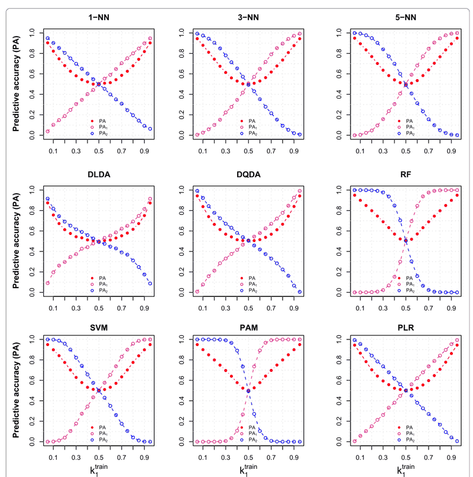

Our run

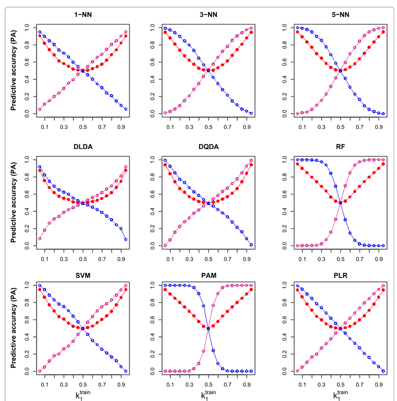

**Fig. 1: null case, p = 40, no selection; PA, PA1, PA2 against k1train (nine classifiers)**

473 of 513 values within tolerance, Partly agrees

(1) SVM: the paper gives no cost, and its class weights ('the proportion of samples from each class') leave the direction open. With the default cost 1 our SVM is less biased than the paper's in the simulations (Additional file 3, k1train 0.1: PA1 0.18 against 0.03; there the weights change nothing at cost 1). A smaller cost with the stated weights brings Additional file 3 back (cost 0.1: 0.08; 0.03: 0.00) but sends the null case of Fig. 2 to 0 (cost 0.1: 0.001 against 0.038). On the breast cancer data the stated weights go the wrong way (20 ER+ / 5 ER-, PA ER-: 0.46 at cost 1 against 0.6); weights inverse to the class sizes with cost 0.1 give 0.60 there but 0.56 at 45 ER+ / 5 ER- (paper 0.49). Weights taken from the original rather than the over-sampled training set change nothing (Additional file 8, k1train 0.1: PA1 0.22 and 0.22). No cost and weighting of the grid fits all of them. (2) PAM without correction: our PAM is slightly more biased than the paper's near balance in the null case (Fig. 1, k1train 0.45: PA1 0.23 against 0.27) and at 45 ER+ / 5 ER- (PA ER- 0.47 against 0.53). The paper says the threshold was the one with the smallest training error, not which one of the ties. The smallest tied threshold gives 0.24 and 0.47; 10-fold CV 0.09 and 0.56; equal class priors 0.46 and 0.63. None fits both. Without variable selection (Additional file 6) the difference runs the other way: the paper's PAM puts nearly every sample in the majority class (k1train 0.2: PA 0.52), ours less so (0.73). (3) Values near 0 or 1: a few points where our replicates are all or nearly all 0 or 1, so the Monte Carlo tolerance is close to 0, and the paper's values differ from ours by less than 0.003.

## Fig. 2

Fig. 2. Null case with selection of 40 variables: PA1 for p = 40, 1000 and 10000; balanced test set.

Partly agrees

Published

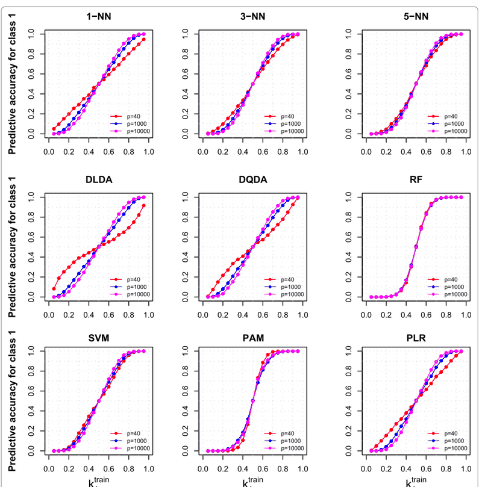

Our run

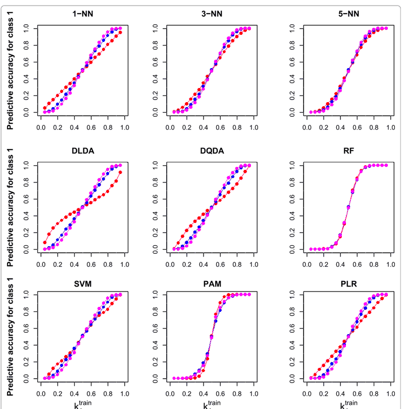

**Fig. 2: null case, G = 40 of p = 40, 1000, 10000; PA1 (nine classifiers)**

469 of 513 values within tolerance, Partly agrees

(1) SVM: the paper gives no cost, and its class weights ('the proportion of samples from each class') leave the direction open. With the default cost 1 our SVM is less biased than the paper's in the simulations (Additional file 3, k1train 0.1: PA1 0.18 against 0.03; there the weights change nothing at cost 1). A smaller cost with the stated weights brings Additional file 3 back (cost 0.1: 0.08; 0.03: 0.00) but sends the null case of Fig. 2 to 0 (cost 0.1: 0.001 against 0.038). On the breast cancer data the stated weights go the wrong way (20 ER+ / 5 ER-, PA ER-: 0.46 at cost 1 against 0.6); weights inverse to the class sizes with cost 0.1 give 0.60 there but 0.56 at 45 ER+ / 5 ER- (paper 0.49). Weights taken from the original rather than the over-sampled training set change nothing (Additional file 8, k1train 0.1: PA1 0.22 and 0.22). No cost and weighting of the grid fits all of them. (2) PAM without correction: our PAM is slightly more biased than the paper's near balance in the null case (Fig. 1, k1train 0.45: PA1 0.23 against 0.27) and at 45 ER+ / 5 ER- (PA ER- 0.47 against 0.53). The paper says the threshold was the one with the smallest training error, not which one of the ties. The smallest tied threshold gives 0.24 and 0.47; 10-fold CV 0.09 and 0.56; equal class priors 0.46 and 0.63. None fits both. Without variable selection (Additional file 6) the difference runs the other way: the paper's PAM puts nearly every sample in the majority class (k1train 0.2: PA 0.52), ours less so (0.73). (3) Values near 0 or 1: a few points where our replicates are all or nearly all 0 or 1, so the Monte Carlo tolerance is close to 0, and the paper's values differ from ours by less than 0.003.

## Fig. 3

Fig. 3. Alternative case, mu2 = 1: PA1 with 20 (left) or all (right) variables differing.

Partly agrees

Published

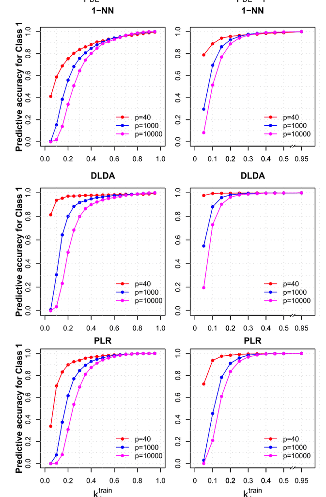

Our run

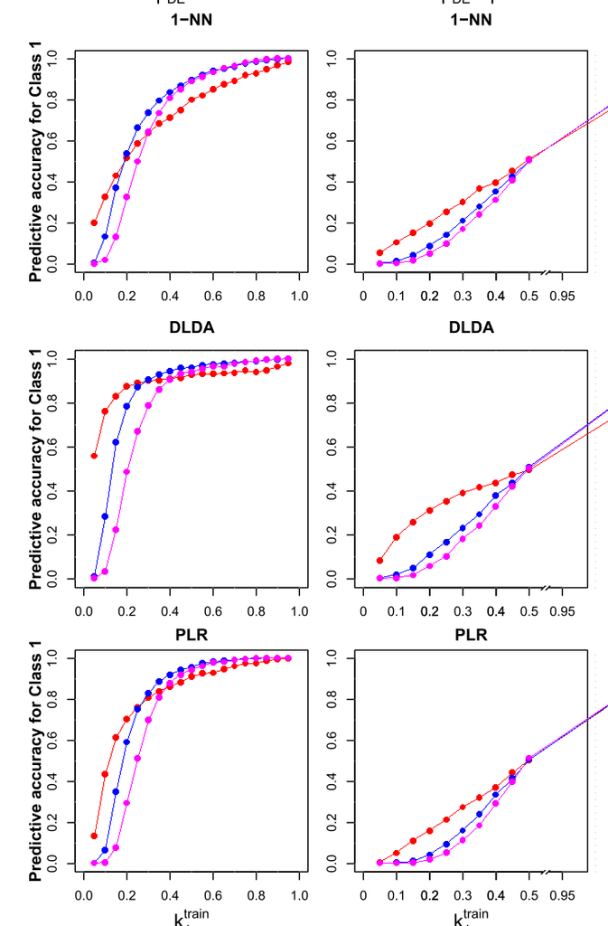

**Fig. 3: alternative case, pDE = 20 or p, G = 40; PA1 (1-NN, DLDA, PLR)**

121 of 270 values within tolerance, Partly agrees

p = 40 and pDE = p: the paper says the samples were centred, and with centring our minority-class PA is far below the paper's where 20 of 40 or all of the variables differ (9 of 156 such points of Fig. 3 match, 32 of 171 of Additional file 4, 27 of 297 of Additional file 5). Centring the samples over 40 variables of which half or all are shifted removes most of the signal. Rerunning these settings without centring (200 replicates) matches 155 of 156 points of Fig. 3, 112 of 171 of Additional file 4 and 254 of 297 of Additional file 5; what still misses is the SVM, PAM at pDE = p, and the k1train = 0.95 end at pDE = 20, where the paper's PA1 is a little lower than either of our runs. Our run keeps the stated centring.

## Fig. 4

Fig. 4. Overall PA against the difference mu2, k1train 0.5 to 0.9; samples (left) or variables (right) centred.

Partly agrees

Published

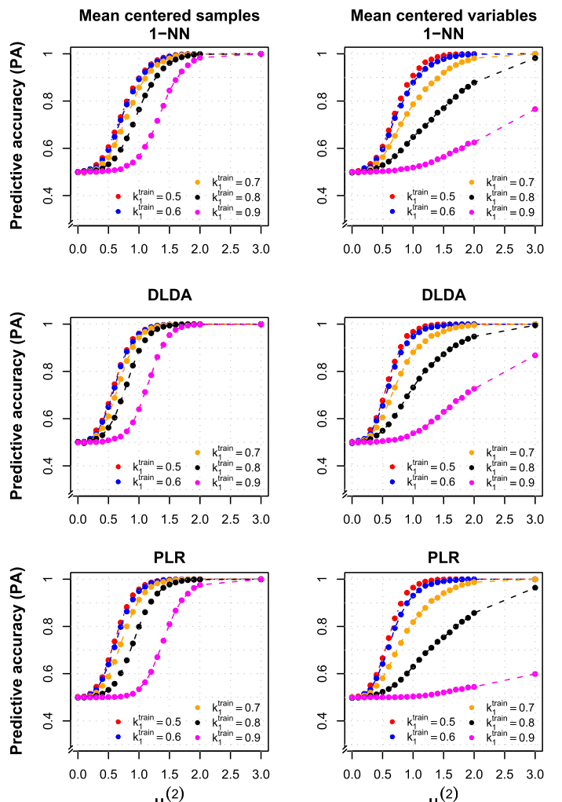

Our run

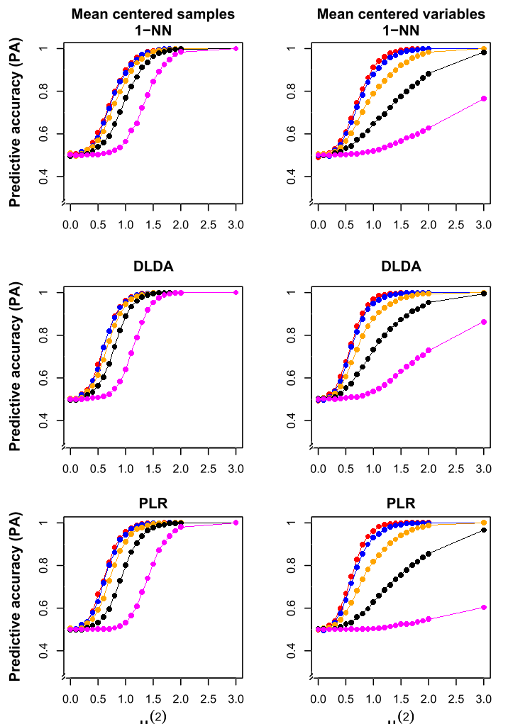

**Fig. 4: overall PA against mu2, k1train 0.5-0.9, centred samples or variables (1-NN, DLDA, PLR)**

659 of 660 values within tolerance, Partly agrees

Values near 0 or 1: a few points where our replicates are all or nearly all 0 or 1, so the Monte Carlo tolerance is close to 0, and the paper's values differ from ours by less than 0.003.

## Fig. 5

Fig. 5. No correction, over-sampling, down-sizing and MultDS, p = 1000.

Partly agrees

Published

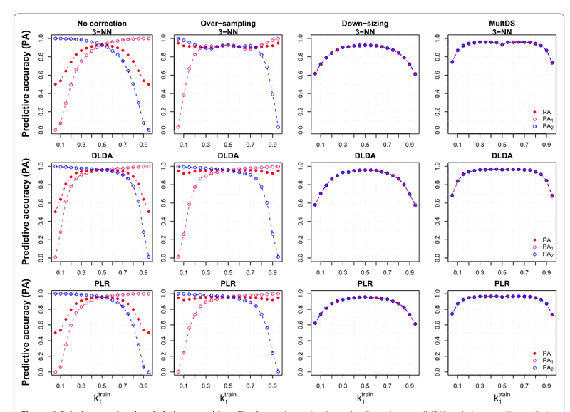

Our run

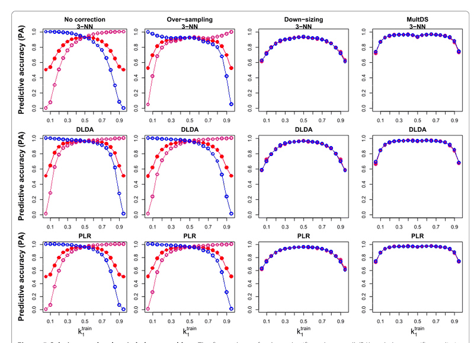

**Fig. 5: no correction, over-sampling, down-sizing, MultDS; PA, PA1, PA2 (3-NN, DLDA, PLR)**

625 of 684 values within tolerance, Partly agrees

(1) Over-sampling, overall PA: Fig. 5's over-sampling PA is the PA of a test set as imbalanced as the training set (k1 PA1 + (1 - k1) PA2 from our class-specific means: 50 of 57 points match, against 19 for the balanced test set the caption implies), while Additional file 8, which repeats the panel for all classifiers, uses the balanced test set (109 of 171 against 59). The two figures disagree; we compare with the balanced test set. (2) Over-sampling, order of selection: with variables selected on the original training set and the classifier fitted on the over-sampled one, DLDA's and DQDA's PA at k1train 0.2 is 0.88 and 0.79 (paper: 0.88, 0.79); selecting on the over-sampled set, which the Methods describe and our run does, gives 0.85 and 0.74. The k-NN classifiers move little either way (3-NN 0.86 / 0.85). (3) Values near 0 or 1: a few points where our replicates are all or nearly all 0 or 1, so the Monte Carlo tolerance is close to 0, and the paper's values differ from ours by less than 0.003.

## Fig. 6

Fig. 6. ER status on the Sotiriou data: class-specific PA (%) and 95% prediction intervals; black no correction, red MultDS.

Partly agrees

Published

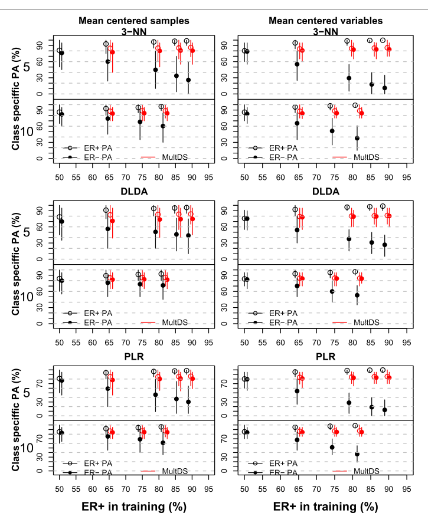

Our run

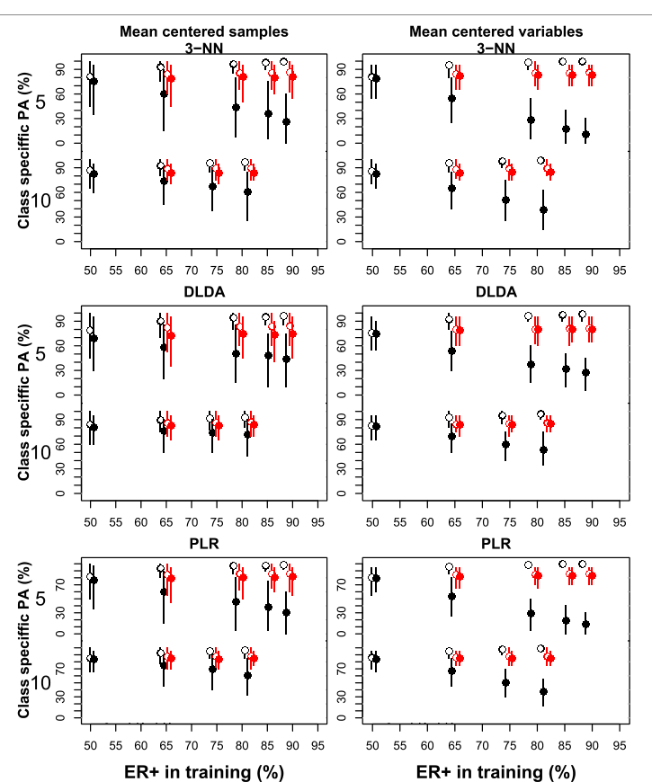

**Fig. 6: ER status, class-specific PA, no correction and MultDS (3-NN, DLDA, PLR), means**

192 of 192 values within tolerance, Agrees

**Fig. 6: 95% prediction intervals of the class-specific PA**

377 of 382 values within tolerance, Partly agrees

Prediction intervals: a few interval ends miss by two steps of 0.05, nearly all lower ends at the smallest training sets (377 of 382 ends of Fig. 6 and 930 of 976 of Additional file 12 match). The lower 2.5th percentile of 500 draws rests on its 13 lowest values, which the paper's draws (unknown seeds) and ours place differently. Other interval definitions fit worse: mean -/+ 1.96 SD matches 310 and 703, 5th and 95th percentiles 361 and 893.

## Additional file 4

Additional file 4. Fig. 3 left for all nine classifiers.

Partly agrees

Published

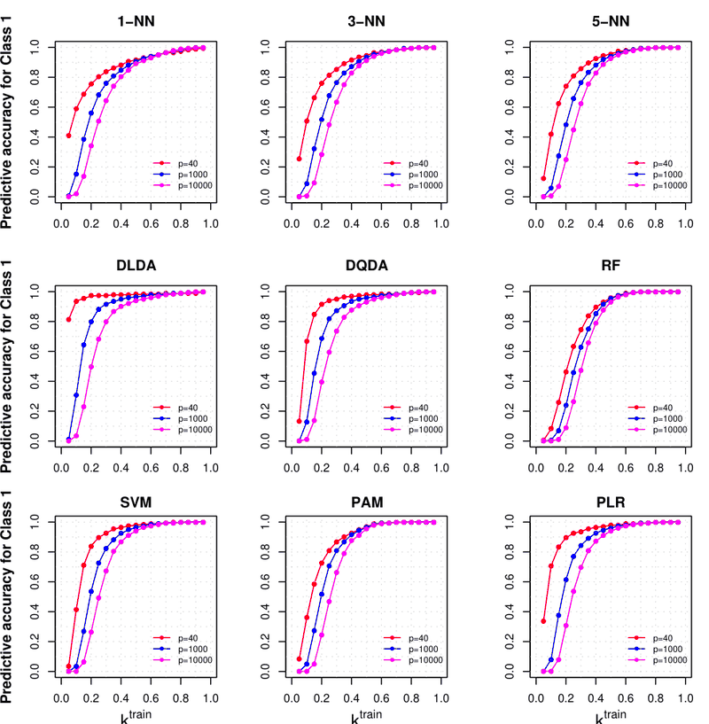

Our run

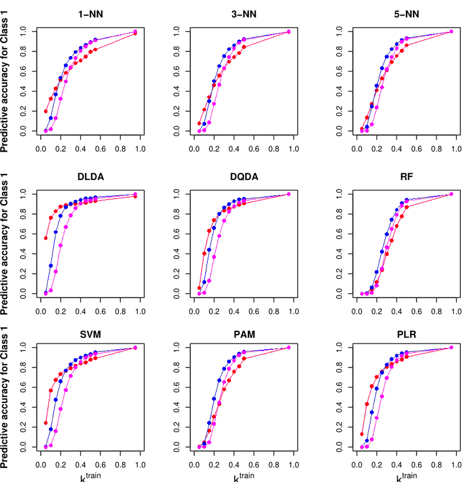

**Additional file 4: Fig. 3 left for all nine classifiers**

241 of 513 values within tolerance, Partly agrees

(1) p = 40 and pDE = p: the paper says the samples were centred, and with centring our minority-class PA is far below the paper's where 20 of 40 or all of the variables differ (9 of 156 such points of Fig. 3 match, 32 of 171 of Additional file 4, 27 of 297 of Additional file 5). Centring the samples over 40 variables of which half or all are shifted removes most of the signal. Rerunning these settings without centring (200 replicates) matches 155 of 156 points of Fig. 3, 112 of 171 of Additional file 4 and 254 of 297 of Additional file 5; what still misses is the SVM, PAM at pDE = p, and the k1train = 0.95 end at pDE = 20, where the paper's PA1 is a little lower than either of our runs. Our run keeps the stated centring. (2) SVM: the paper gives no cost, and its class weights ('the proportion of samples from each class') leave the direction open. With the default cost 1 our SVM is less biased than the paper's in the simulations (Additional file 3, k1train 0.1: PA1 0.18 against 0.03; there the weights change nothing at cost 1). A smaller cost with the stated weights brings Additional file 3 back (cost 0.1: 0.08; 0.03: 0.00) but sends the null case of Fig. 2 to 0 (cost 0.1: 0.001 against 0.038). On the breast cancer data the stated weights go the wrong way (20 ER+ / 5 ER-, PA ER-: 0.46 at cost 1 against 0.6); weights inverse to the class sizes with cost 0.1 give 0.60 there but 0.56 at 45 ER+ / 5 ER- (paper 0.49). Weights taken from the original rather than the over-sampled training set change nothing (Additional file 8, k1train 0.1: PA1 0.22 and 0.22). No cost and weighting of the grid fits all of them.

## Additional file 5

Additional file 5. Fig. 3 right for all nine classifiers.

Partly agrees

Published

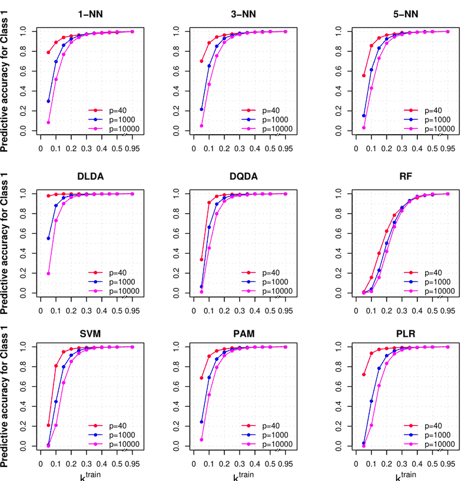

Our run

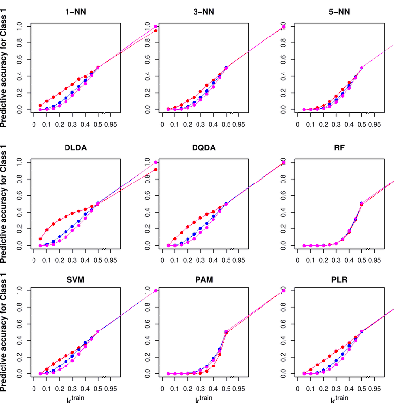

**Additional file 5: Fig. 3 right (pDE = p) for all nine classifiers**

27 of 297 values within tolerance, Partly agrees

(1) p = 40 and pDE = p: the paper says the samples were centred, and with centring our minority-class PA is far below the paper's where 20 of 40 or all of the variables differ (9 of 156 such points of Fig. 3 match, 32 of 171 of Additional file 4, 27 of 297 of Additional file 5). Centring the samples over 40 variables of which half or all are shifted removes most of the signal. Rerunning these settings without centring (200 replicates) matches 155 of 156 points of Fig. 3, 112 of 171 of Additional file 4 and 254 of 297 of Additional file 5; what still misses is the SVM, PAM at pDE = p, and the k1train = 0.95 end at pDE = 20, where the paper's PA1 is a little lower than either of our runs. Our run keeps the stated centring. (2) SVM: the paper gives no cost, and its class weights ('the proportion of samples from each class') leave the direction open. With the default cost 1 our SVM is less biased than the paper's in the simulations (Additional file 3, k1train 0.1: PA1 0.18 against 0.03; there the weights change nothing at cost 1). A smaller cost with the stated weights brings Additional file 3 back (cost 0.1: 0.08; 0.03: 0.00) but sends the null case of Fig. 2 to 0 (cost 0.1: 0.001 against 0.038). On the breast cancer data the stated weights go the wrong way (20 ER+ / 5 ER-, PA ER-: 0.46 at cost 1 against 0.6); weights inverse to the class sizes with cost 0.1 give 0.60 there but 0.56 at 45 ER+ / 5 ER- (paper 0.49). Weights taken from the original rather than the over-sampled training set change nothing (Additional file 8, k1train 0.1: PA1 0.22 and 0.22). No cost and weighting of the grid fits all of them.

## Additional file 6

Additional file 6. No variable selection (all 1000 variables), Fig. 5 first column, all nine classifiers.

Partly agrees

Published

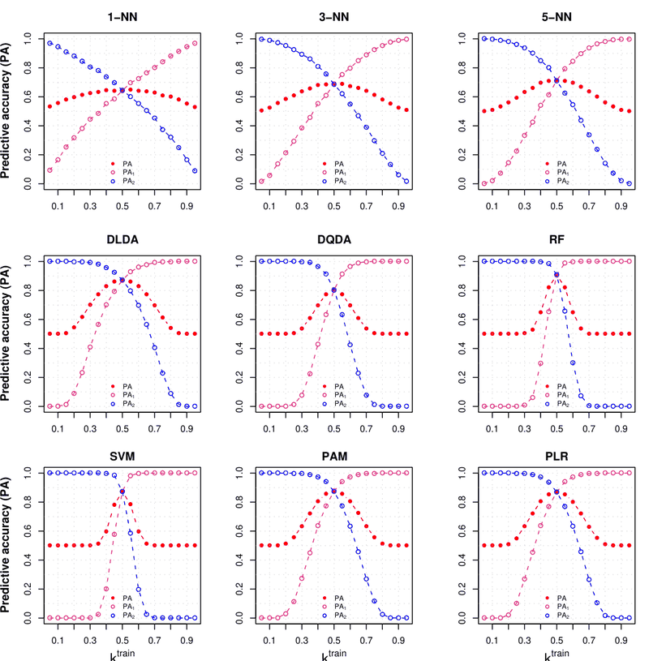

Our run

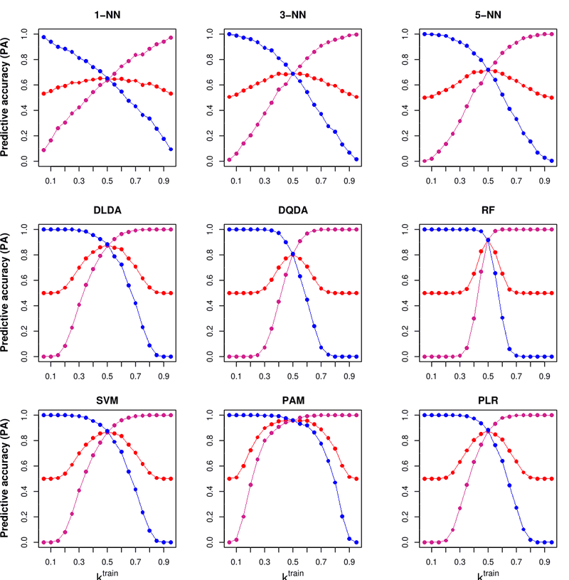

**Additional file 6: no variable selection (G = p = 1000), Fig. 5 first column; PA, PA1, PA2 (nine classifiers)**

440 of 513 values within tolerance, Partly agrees

(1) SVM: the paper gives no cost, and its class weights ('the proportion of samples from each class') leave the direction open. With the default cost 1 our SVM is less biased than the paper's in the simulations (Additional file 3, k1train 0.1: PA1 0.18 against 0.03; there the weights change nothing at cost 1). A smaller cost with the stated weights brings Additional file 3 back (cost 0.1: 0.08; 0.03: 0.00) but sends the null case of Fig. 2 to 0 (cost 0.1: 0.001 against 0.038). On the breast cancer data the stated weights go the wrong way (20 ER+ / 5 ER-, PA ER-: 0.46 at cost 1 against 0.6); weights inverse to the class sizes with cost 0.1 give 0.60 there but 0.56 at 45 ER+ / 5 ER- (paper 0.49). Weights taken from the original rather than the over-sampled training set change nothing (Additional file 8, k1train 0.1: PA1 0.22 and 0.22). No cost and weighting of the grid fits all of them. (2) PAM without correction: our PAM is slightly more biased than the paper's near balance in the null case (Fig. 1, k1train 0.45: PA1 0.23 against 0.27) and at 45 ER+ / 5 ER- (PA ER- 0.47 against 0.53). The paper says the threshold was the one with the smallest training error, not which one of the ties. The smallest tied threshold gives 0.24 and 0.47; 10-fold CV 0.09 and 0.56; equal class priors 0.46 and 0.63. None fits both. Without variable selection (Additional file 6) the difference runs the other way: the paper's PAM puts nearly every sample in the majority class (k1train 0.2: PA 0.52), ours less so (0.73). (3) Values near 0 or 1: a few points where our replicates are all or nearly all 0 or 1, so the Monte Carlo tolerance is close to 0, and the paper's values differ from ours by less than 0.003.

## Additional file 7

Additional file 7. Fig. 4 for all nine classifiers.

Partly agrees

Published

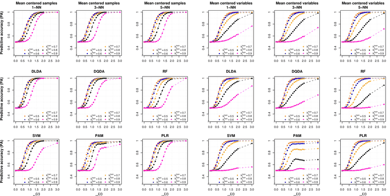

Our run

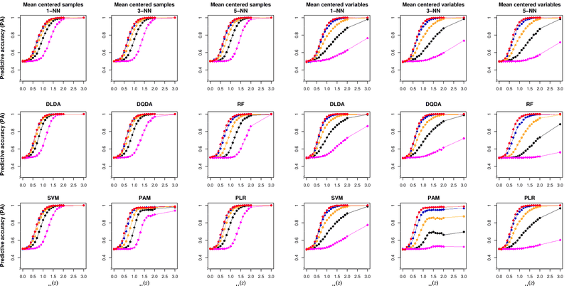

**Additional file 7: Fig. 4 for all nine classifiers**

1894 of 1980 values within tolerance, Partly agrees

SVM: the paper gives no cost, and its class weights ('the proportion of samples from each class') leave the direction open. With the default cost 1 our SVM is less biased than the paper's in the simulations (Additional file 3, k1train 0.1: PA1 0.18 against 0.03; there the weights change nothing at cost 1). A smaller cost with the stated weights brings Additional file 3 back (cost 0.1: 0.08; 0.03: 0.00) but sends the null case of Fig. 2 to 0 (cost 0.1: 0.001 against 0.038). On the breast cancer data the stated weights go the wrong way (20 ER+ / 5 ER-, PA ER-: 0.46 at cost 1 against 0.6); weights inverse to the class sizes with cost 0.1 give 0.60 there but 0.56 at 45 ER+ / 5 ER- (paper 0.49). Weights taken from the original rather than the over-sampled training set change nothing (Additional file 8, k1train 0.1: PA1 0.22 and 0.22). No cost and weighting of the grid fits all of them.

## Additional file 8

Additional file 8. Fig. 5 for all nine classifiers (MultDS run for six).

Partly agrees

Published

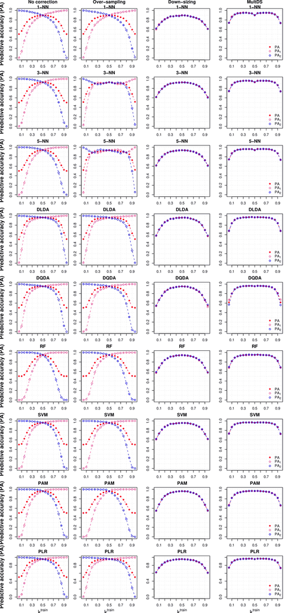

Our run

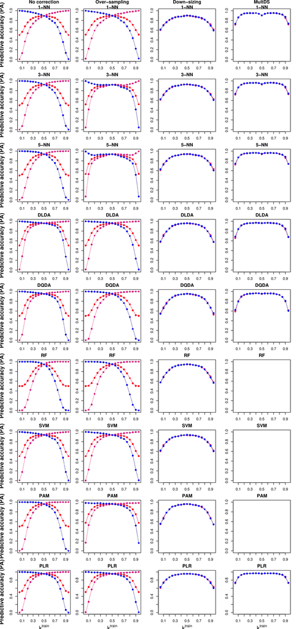

**Additional file 8: Fig. 5 for all nine classifiers (MultDS for six)**

1655 of 1881 values within tolerance, Partly agrees

(1) SVM: the paper gives no cost, and its class weights ('the proportion of samples from each class') leave the direction open. With the default cost 1 our SVM is less biased than the paper's in the simulations (Additional file 3, k1train 0.1: PA1 0.18 against 0.03; there the weights change nothing at cost 1). A smaller cost with the stated weights brings Additional file 3 back (cost 0.1: 0.08; 0.03: 0.00) but sends the null case of Fig. 2 to 0 (cost 0.1: 0.001 against 0.038). On the breast cancer data the stated weights go the wrong way (20 ER+ / 5 ER-, PA ER-: 0.46 at cost 1 against 0.6); weights inverse to the class sizes with cost 0.1 give 0.60 there but 0.56 at 45 ER+ / 5 ER- (paper 0.49). Weights taken from the original rather than the over-sampled training set change nothing (Additional file 8, k1train 0.1: PA1 0.22 and 0.22). No cost and weighting of the grid fits all of them. (2) PAM with over-sampling: the paper's PAM stays fully biased after over-sampling (Additional file 8, k1train 0.1: PA 0.51; Additional file 9, k1train 0.05: PA1 0.02), ours does not (0.75, 0.74): pamr's class prior defaults to the class shares of the set it is trained on, which over-sampling makes equal. Keeping the prior of the original training set gives 0.51 and 0.06. (3) Over-sampling, order of selection: with variables selected on the original training set and the classifier fitted on the over-sampled one, DLDA's and DQDA's PA at k1train 0.2 is 0.88 and 0.79 (paper: 0.88, 0.79); selecting on the over-sampled set, which the Methods describe and our run does, gives 0.85 and 0.74. The k-NN classifiers move little either way (3-NN 0.86 / 0.85). (4) Over-sampling, overall PA: Fig. 5's over-sampling PA is the PA of a test set as imbalanced as the training set (k1 PA1 + (1 - k1) PA2 from our class-specific means: 50 of 57 points match, against 19 for the balanced test set the caption implies), while Additional file 8, which repeats the panel for all classifiers, uses the balanced test set (109 of 171 against 59). The two figures disagree; we compare with the balanced test set.

## Additional file 9

Additional file 9. Over-sampling, then centred variables; balanced test set (odd columns) or as imbalanced as training.

Partly agrees

Published

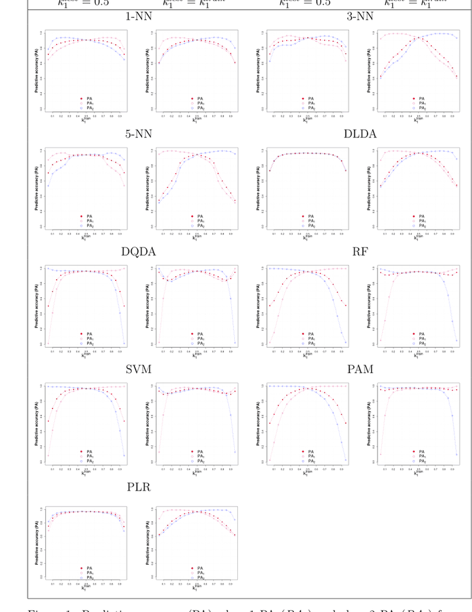

Our run

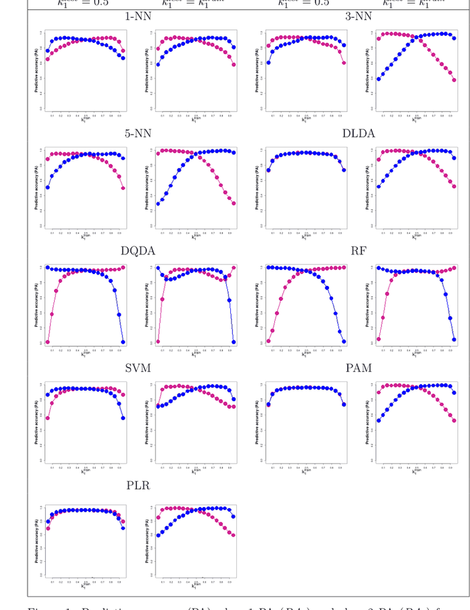

**Additional file 9: over-sampling with centred variables, balanced test set; PA, PA1, PA2 (nine classifiers)**

510 of 684 values within tolerance, Partly agrees

(1) PAM with over-sampling: the paper's PAM stays fully biased after over-sampling (Additional file 8, k1train 0.1: PA 0.51; Additional file 9, k1train 0.05: PA1 0.02), ours does not (0.75, 0.74): pamr's class prior defaults to the class shares of the set it is trained on, which over-sampling makes equal. Keeping the prior of the original training set gives 0.51 and 0.06. (2) SVM: the paper gives no cost, and its class weights ('the proportion of samples from each class') leave the direction open. With the default cost 1 our SVM is less biased than the paper's in the simulations (Additional file 3, k1train 0.1: PA1 0.18 against 0.03; there the weights change nothing at cost 1). A smaller cost with the stated weights brings Additional file 3 back (cost 0.1: 0.08; 0.03: 0.00) but sends the null case of Fig. 2 to 0 (cost 0.1: 0.001 against 0.038). On the breast cancer data the stated weights go the wrong way (20 ER+ / 5 ER-, PA ER-: 0.46 at cost 1 against 0.6); weights inverse to the class sizes with cost 0.1 give 0.60 there but 0.56 at 45 ER+ / 5 ER- (paper 0.49). Weights taken from the original rather than the over-sampled training set change nothing (Additional file 8, k1train 0.1: PA1 0.22 and 0.22). No cost and weighting of the grid fits all of them. (3) Over-sampling, order of selection: with variables selected on the original training set and the classifier fitted on the over-sampled one, DLDA's and DQDA's PA at k1train 0.2 is 0.88 and 0.79 (paper: 0.88, 0.79); selecting on the over-sampled set, which the Methods describe and our run does, gives 0.85 and 0.74. The k-NN classifiers move little either way (3-NN 0.86 / 0.85).

## Additional file 10

Additional file 10. 95% prediction intervals of the overall PA.

Exact

Published

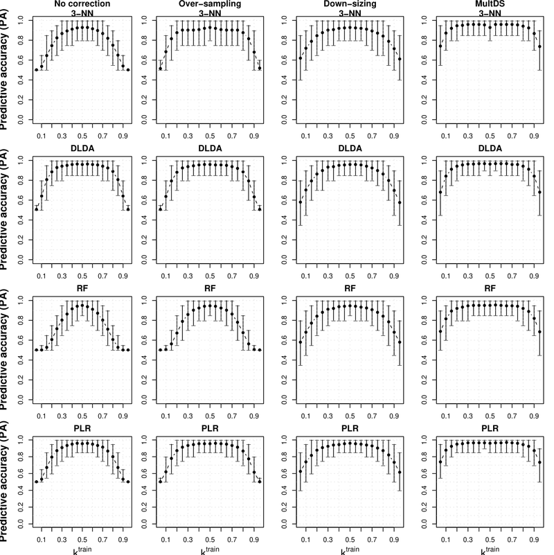

Our run

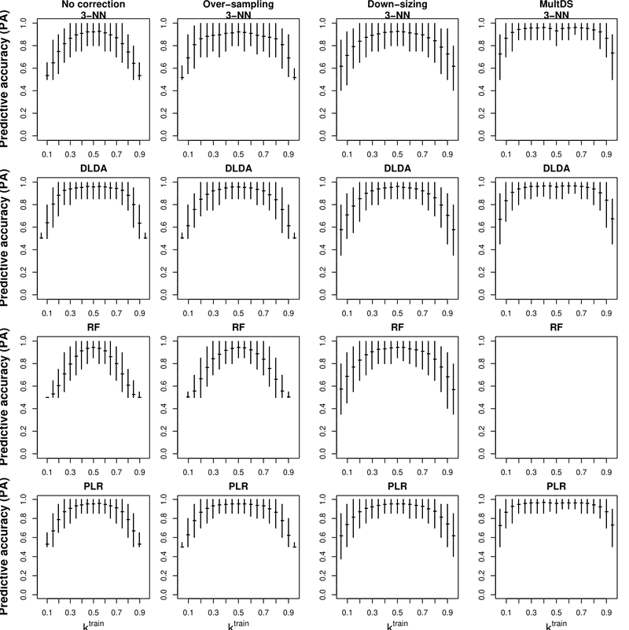

**Additional file 10: 95% prediction intervals of the overall PA, four corrections (3-NN, DLDA, RF, PLR; MultDS not run for RF)**

554 of 554 values within tolerance, Exact

Additional file 10's caption says the test sets held 500 samples, but its interval ends all sit on a 0.05 grid, which only a 20-sample test set gives. Compared with our 20-sample test sets, 554 of 554 interval ends match within one step; with 500-sample test sets, 12 of 554.

## Additional file 11

Additional file 11. RF-THR and PLR-THR.

Exact

Published

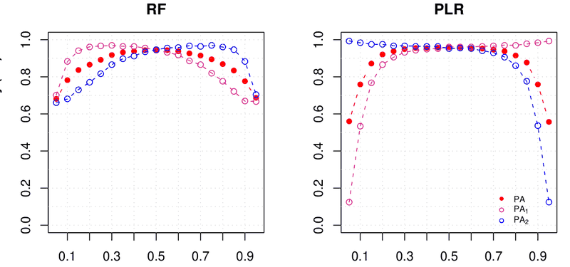

Our run

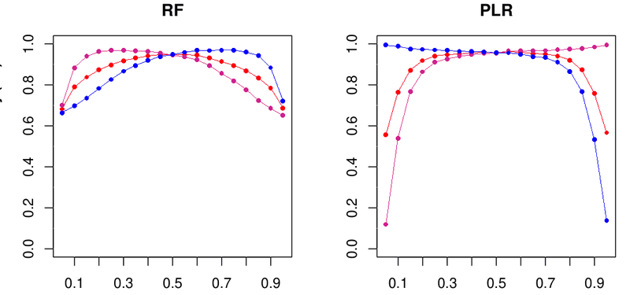

**Additional file 11: RF-THR and PLR-THR; PA, PA1, PA2**

114 of 114 values within tolerance, Exact

## Additional file 12

Additional file 12. Fig. 6 for all nine classifiers (intervals compared).

Partly agrees

Published

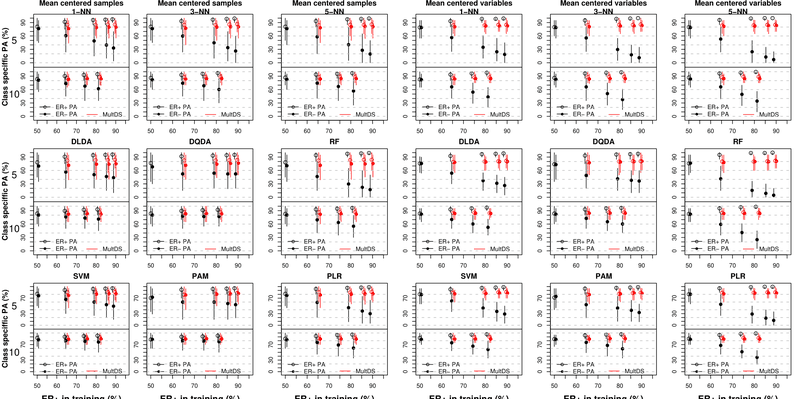

Our run

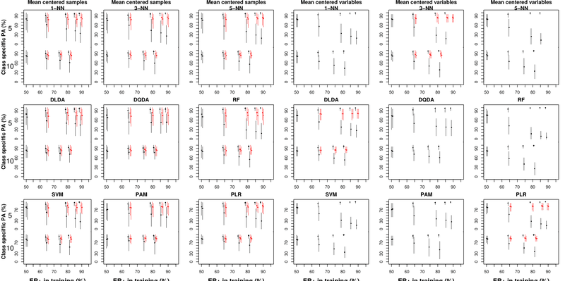

**Additional file 12: Fig. 6 for all nine classifiers, 95% prediction intervals (MultDS with centred variables run for 3-NN, DLDA and PLR only)**

930 of 976 values within tolerance, Partly agrees

(1) SVM: the paper gives no cost, and its class weights ('the proportion of samples from each class') leave the direction open. With the default cost 1 our SVM is less biased than the paper's in the simulations (Additional file 3, k1train 0.1: PA1 0.18 against 0.03; there the weights change nothing at cost 1). A smaller cost with the stated weights brings Additional file 3 back (cost 0.1: 0.08; 0.03: 0.00) but sends the null case of Fig. 2 to 0 (cost 0.1: 0.001 against 0.038). On the breast cancer data the stated weights go the wrong way (20 ER+ / 5 ER-, PA ER-: 0.46 at cost 1 against 0.6); weights inverse to the class sizes with cost 0.1 give 0.60 there but 0.56 at 45 ER+ / 5 ER- (paper 0.49). Weights taken from the original rather than the over-sampled training set change nothing (Additional file 8, k1train 0.1: PA1 0.22 and 0.22). No cost and weighting of the grid fits all of them. (2) PAM without correction: our PAM is slightly more biased than the paper's near balance in the null case (Fig. 1, k1train 0.45: PA1 0.23 against 0.27) and at 45 ER+ / 5 ER- (PA ER- 0.47 against 0.53). The paper says the threshold was the one with the smallest training error, not which one of the ties. The smallest tied threshold gives 0.24 and 0.47; 10-fold CV 0.09 and 0.56; equal class priors 0.46 and 0.63. None fits both. Without variable selection (Additional file 6) the difference runs the other way: the paper's PAM puts nearly every sample in the majority class (k1train 0.2: PA 0.52), ours less so (0.73). (3) Prediction intervals: a few interval ends miss by two steps of 0.05, nearly all lower ends at the smallest training sets (377 of 382 ends of Fig. 6 and 930 of 976 of Additional file 12 match). The lower 2.5th percentile of 500 draws rests on its 13 lowest values, which the paper's draws (unknown seeds) and ours place differently. Other interval definitions fit worse: mean -/+ 1.96 SD matches 310 and 703, 5th and 95th percentiles 361 and 893.

## The tables

Every cell of the four tables in the additional files: the simulations of Additional files 1 and 3 and the breast cancer tables 13 and 14.

## Additional file 1

Additional file 1: null case, p = 40, balanced test sets of 20 and 500; PA, PA1, PA2, PV1, PV2, AUC. Paper above, ours below; dark shading where ours is outside the tolerance, light where the paper printed another classifier's value. 419 of 419 cells within.

Exact

| Setting | PA | PA1 | PA2 | PV1 | PV2 | AUC |
| --- | --- | --- | --- | --- | --- | --- |
| 1-NN, k1 0.1, ntest 20 | 0.5 0.50 | 0.05 0.10 | 0.95 0.89 | NA NA | 0.9 0.90 | 0.5 0.50 |
| 3-NN, k1 0.1, ntest 20 | 0.5 0.50 | 0.05 0.02 | 0.95 0.97 | NA NA | 0.9 0.90 | 0.5 0.50 |
| 5-NN, k1 0.1, ntest 20 | 0.5 0.50 | 0.05 0.00 | 0.95 0.99 | NA NA | 0.9 0.90 | 0.5 0.49 |
| 1-NN, k1 0.1, ntest 500 | 0.5 0.50 | 0.05 0.10 | 0.95 0.90 | 0.11 0.10 | 0.9 0.90 | 0.5 0.50 |
| 3-NN, k1 0.1, ntest 500 | 0.5 0.50 | 0.05 0.03 | 0.95 0.97 | 0.11 0.15 | 0.9 0.90 | 0.5 0.50 |
| 5-NN, k1 0.1, ntest 500 | 0.5 0.50 | 0.05 0.01 | 0.95 0.99 | 0.11 0.29 | 0.9 0.90 | 0.5 0.50 |
| 1-NN, k1 0.2, ntest 20 | 0.5 0.50 | 0.15 0.20 | 0.84 0.81 | 0.32 0.30 | 0.8 0.80 | 0.49 0.50 |
| 3-NN, k1 0.2, ntest 20 | 0.5 0.50 | 0.15 0.10 | 0.84 0.91 | 0.32 0.37 | 0.8 0.80 | 0.5 0.50 |
| 5-NN, k1 0.2, ntest 20 | 0.5 0.50 | 0.15 0.05 | 0.84 0.95 | 0.32 0.41 | 0.8 0.80 | 0.5 0.50 |
| 1-NN, k1 0.2, ntest 500 | 0.5 0.50 | 0.16 0.20 | 0.84 0.81 | 0.2 0.20 | 0.8 0.80 | 0.5 0.50 |
| 3-NN, k1 0.2, ntest 500 | 0.5 0.50 | 0.16 0.10 | 0.84 0.90 | 0.2 0.21 | 0.8 0.80 | 0.5 0.50 |
| 5-NN, k1 0.2, ntest 500 | 0.5 0.50 | 0.16 0.05 | 0.84 0.95 | 0.2 0.22 | 0.8 0.80 | 0.5 0.50 |
| 1-NN, k1 0.3, ntest 20 | 0.5 0.50 | 0.27 0.30 | 0.73 0.71 | 0.34 0.34 | 0.7 0.70 | 0.5 0.50 |
| 3-NN, k1 0.3, ntest 20 | 0.5 0.50 | 0.27 0.21 | 0.73 0.79 | 0.34 0.36 | 0.7 0.70 | 0.5 0.50 |
| 5-NN, k1 0.3, ntest 20 | 0.5 0.50 | 0.27 0.15 | 0.73 0.85 | 0.34 0.39 | 0.7 0.70 | 0.5 0.50 |
| 1-NN, k1 0.3, ntest 500 | 0.5 0.50 | 0.27 0.30 | 0.73 0.70 | 0.3 0.30 | 0.7 0.70 | 0.5 0.50 |
| 3-NN, k1 0.3, ntest 500 | 0.5 0.50 | 0.27 0.21 | 0.73 0.79 | 0.3 0.30 | 0.7 0.70 | 0.5 0.50 |
| 5-NN, k1 0.3, ntest 500 | 0.5 0.50 | 0.27 0.15 | 0.73 0.85 | 0.3 0.30 | 0.7 0.70 | 0.5 0.50 |
| 1-NN, k1 0.4, ntest 20 | 0.5 0.50 | 0.38 0.40 | 0.62 0.60 | 0.41 0.41 | 0.6 0.59 | 0.5 0.50 |
| 3-NN, k1 0.4, ntest 20 | 0.5 0.50 | 0.38 0.35 | 0.62 0.66 | 0.41 0.41 | 0.6 0.60 | 0.5 0.50 |
| 5-NN, k1 0.4, ntest 20 | 0.5 0.50 | 0.38 0.31 | 0.62 0.69 | 0.41 0.42 | 0.6 0.60 | 0.5 0.50 |
| 1-NN, k1 0.4, ntest 500 | 0.5 0.50 | 0.38 0.40 | 0.61 0.60 | 0.4 0.40 | 0.6 0.60 | 0.5 0.50 |
| 3-NN, k1 0.4, ntest 500 | 0.5 0.50 | 0.38 0.35 | 0.61 0.65 | 0.4 0.40 | 0.6 0.60 | 0.5 0.50 |
| 5-NN, k1 0.4, ntest 500 | 0.5 0.50 | 0.38 0.31 | 0.61 0.69 | 0.4 0.40 | 0.6 0.60 | 0.5 0.50 |
| 1-NN, k1 0.5, ntest 20 | 0.5 0.50 | 0.5 0.49 | 0.5 0.50 | 0.5 0.50 | 0.5 0.49 | 0.5 0.50 |
| 3-NN, k1 0.5, ntest 20 | 0.5 0.50 | 0.5 0.49 | 0.5 0.50 | 0.5 0.50 | 0.5 0.50 | 0.5 0.50 |
| 5-NN, k1 0.5, ntest 20 | 0.5 0.50 | 0.5 0.50 | 0.5 0.50 | 0.5 0.50 | 0.5 0.50 | 0.5 0.50 |
| 1-NN, k1 0.5, ntest 500 | 0.5 0.50 | 0.5 0.50 | 0.5 0.50 | 0.5 0.50 | 0.5 0.50 | 0.5 0.50 |
| 3-NN, k1 0.5, ntest 500 | 0.5 0.50 | 0.5 0.50 | 0.5 0.50 | 0.5 0.50 | 0.5 0.50 | 0.5 0.50 |
| 5-NN, k1 0.5, ntest 500 | 0.5 0.50 | 0.5 0.50 | 0.5 0.50 | 0.5 0.50 | 0.5 0.50 | 0.5 0.50 |

[output cut: 60 more lines]

## Additional file 3

Additional file 3: alternative case, p = 1000, pDE = 20, mu2 = 1, test sets of 20 and 500; all measures. Paper above, ours below; dark shading where ours is outside the tolerance, light where the paper printed another classifier's value. 500 of 540 cells within.

Partly agrees

| Setting | PA | PA1 | PA2 | PV1 | PV2 | AUC |
| --- | --- | --- | --- | --- | --- | --- |
| 1-NN, k1 0.1, ntest 20 | 0.57 0.56 | 0.14 0.13 | 1 1.00 | NA NA | 0.91 0.91 | 0.57 0.56 |
| 3-NN, k1 0.1, ntest 20 | 0.54 0.54 | 0.08 0.07 | 1 1.00 | NA NA | 0.91 0.91 | 0.64 0.63 |
| 5-NN, k1 0.1, ntest 20 | 0.52 0.52 | 0.05 0.04 | 1 1.00 | NA NA | 0.9 0.90 | 0.68 0.68 |
| 1-NN, k1 0.1, ntest 500 | 0.57 0.57 | 0.13 0.14 | 1 1.00 | 0.86 0.87 | 0.91 0.91 | 0.57 0.57 |
| 3-NN, k1 0.1, ntest 500 | 0.54 0.54 | 0.08 0.08 | 1 1.00 | 0.96 0.97 | 0.91 0.91 | 0.64 0.64 |
| 5-NN, k1 0.1, ntest 500 | 0.52 0.52 | 0.05 0.05 | 1 1.00 | 0.99 0.98 | 0.9 0.90 | 0.68 0.68 |
| 1-NN, k1 0.2, ntest 20 | 0.76 0.76 | 0.53 0.54 | 0.98 0.98 | 0.94 0.92 | 0.9 0.90 | 0.76 0.76 |
| 3-NN, k1 0.2, ntest 20 | 0.74 0.75 | 0.49 0.50 | 1 0.99 | 0.98 0.98 | 0.89 0.89 | 0.88 0.88 |
| 5-NN, k1 0.2, ntest 20 | 0.73 0.73 | 0.45 0.46 | 1 1.00 | 0.99 0.99 | 0.88 0.88 | 0.92 0.92 |
| 1-NN, k1 0.2, ntest 500 | 0.76 0.76 | 0.54 0.54 | 0.98 0.98 | 0.9 0.89 | 0.9 0.90 | 0.77 0.76 |
| 3-NN, k1 0.2, ntest 500 | 0.75 0.75 | 0.5 0.50 | 0.99 0.99 | 0.96 0.96 | 0.89 0.89 | 0.88 0.88 |
| 5-NN, k1 0.2, ntest 500 | 0.73 0.73 | 0.47 0.46 | 1 1.00 | 0.98 0.98 | 0.88 0.88 | 0.92 0.92 |
| 1-NN, k1 0.3, ntest 20 | 0.85 0.85 | 0.74 0.74 | 0.96 0.96 | 0.92 0.91 | 0.9 0.90 | 0.85 0.85 |
| 3-NN, k1 0.3, ntest 20 | 0.87 0.87 | 0.75 0.75 | 0.98 0.98 | 0.96 0.96 | 0.91 0.91 | 0.94 0.95 |
| 5-NN, k1 0.3, ntest 20 | 0.87 0.87 | 0.75 0.75 | 0.99 0.99 | 0.97 0.98 | 0.9 0.91 | 0.97 0.97 |
| 1-NN, k1 0.3, ntest 500 | 0.85 0.85 | 0.74 0.74 | 0.96 0.96 | 0.9 0.90 | 0.9 0.90 | 0.85 0.85 |
| 3-NN, k1 0.3, ntest 500 | 0.87 0.87 | 0.75 0.75 | 0.98 0.98 | 0.95 0.95 | 0.9 0.90 | 0.94 0.95 |
| 5-NN, k1 0.3, ntest 500 | 0.87 0.87 | 0.74 0.75 | 0.99 0.99 | 0.97 0.97 | 0.9 0.90 | 0.97 0.97 |
| 1-NN, k1 0.4, ntest 20 | 0.89 0.88 | 0.84 0.84 | 0.94 0.93 | 0.91 0.91 | 0.9 0.90 | 0.89 0.88 |
| 3-NN, k1 0.4, ntest 20 | 0.91 0.91 | 0.86 0.86 | 0.96 0.96 | 0.95 0.95 | 0.92 0.92 | 0.97 0.96 |
| 5-NN, k1 0.4, ntest 20 | 0.92 0.92 | 0.87 0.87 | 0.97 0.97 | 0.96 0.96 | 0.92 0.92 | 0.98 0.98 |
| 1-NN, k1 0.4, ntest 500 | 0.89 0.89 | 0.84 0.84 | 0.94 0.94 | 0.9 0.90 | 0.9 0.90 | 0.89 0.89 |
| 3-NN, k1 0.4, ntest 500 | 0.92 0.92 | 0.87 0.87 | 0.96 0.96 | 0.94 0.94 | 0.92 0.92 | 0.96 0.96 |
| 5-NN, k1 0.4, ntest 500 | 0.92 0.92 | 0.88 0.88 | 0.97 0.97 | 0.96 0.96 | 0.92 0.92 | 0.98 0.98 |
| 1-NN, k1 0.5, ntest 20 | 0.9 0.89 | 0.9 0.89 | 0.9 0.90 | 0.9 0.90 | 0.91 0.90 | 0.9 0.89 |
| 3-NN, k1 0.5, ntest 20 | 0.93 0.92 | 0.93 0.92 | 0.93 0.92 | 0.93 0.93 | 0.93 0.93 | 0.97 0.97 |
| 5-NN, k1 0.5, ntest 20 | 0.94 0.94 | 0.94 0.93 | 0.94 0.94 | 0.95 0.94 | 0.95 0.94 | 0.98 0.98 |
| 1-NN, k1 0.5, ntest 500 | 0.9 0.90 | 0.9 0.90 | 0.9 0.90 | 0.9 0.90 | 0.9 0.90 | 0.9 0.90 |
| 3-NN, k1 0.5, ntest 500 | 0.93 0.93 | 0.93 0.93 | 0.93 0.93 | 0.93 0.93 | 0.93 0.93 | 0.97 0.97 |
| 5-NN, k1 0.5, ntest 500 | 0.94 0.94 | 0.94 0.94 | 0.94 0.94 | 0.94 0.94 | 0.94 0.94 | 0.98 0.98 |

[output cut: 60 more lines]

(1) SVM: the paper gives no cost, and its class weights ('the proportion of samples from each class') leave the direction open. With the default cost 1 our SVM is less biased than the paper's in the simulations (Additional file 3, k1train 0.1: PA1 0.18 against 0.03; there the weights change nothing at cost 1). A smaller cost with the stated weights brings Additional file 3 back (cost 0.1: 0.08; 0.03: 0.00) but sends the null case of Fig. 2 to 0 (cost 0.1: 0.001 against 0.038). On the breast cancer data the stated weights go the wrong way (20 ER+ / 5 ER-, PA ER-: 0.46 at cost 1 against 0.6); weights inverse to the class sizes with cost 0.1 give 0.60 there but 0.56 at 45 ER+ / 5 ER- (paper 0.49). Weights taken from the original rather than the over-sampled training set change nothing (Additional file 8, k1train 0.1: PA1 0.22 and 0.22). No cost and weighting of the grid fits all of them. (2) DQDA's AUC: lower than the paper's when the training set is imbalanced (k1train 0.1: 0.87 against 0.91). The paper does not say which score it ranked. Ranking by the ratio of the two discriminants instead of their difference gives the paper's AUC at every k1train (0.91, 0.98, 0.99, 0.99, 0.99) and moves DLDA's AUC only from 0.94 to 0.95 at 0.1 (paper 0.94); the predictions do not change. Found by search over five scores; our run keeps the difference.

## Additional file 13

Additional file 13: ER status, no correction; all measures, nine classifiers. Paper above, ours below; dark shading where ours is outside the tolerance, light where the paper printed another classifier's value. 440 of 486 cells within.

Partly agrees

| Setting | PA | PA_ER+ | PA_ER- | PV_ER+ | PV_ER- | AUC |
| --- | --- | --- | --- | --- | --- | --- |
| 1-NN, 5 ER+ / 5 ER- | 0.78 0.78 | 0.81 0.81 | 0.75 0.75 | 0.78 0.78 | 0.81 0.81 | 0.78 0.78 |
| 3-NN, 5 ER+ / 5 ER- | 0.79 0.78 | 0.82 0.81 | 0.75 0.75 | 0.78 0.78 | 0.82 0.81 | 0.82 0.82 |
| 5-NN, 5 ER+ / 5 ER- | 0.78 0.79 | 0.81 0.81 | 0.76 0.76 | 0.78 0.79 | 0.81 0.81 | 0.84 0.84 |
| 1-NN, 10 ER+ / 5 ER- | 0.76 0.76 | 0.92 0.91 | 0.61 0.62 | 0.83 0.83 | 0.8 0.80 | 0.77 0.76 |
| 3-NN, 10 ER+ / 5 ER- | 0.77 0.76 | 0.93 0.93 | 0.6 0.60 | 0.83 0.83 | 0.83 0.82 | 0.82 0.82 |
| 5-NN, 10 ER+ / 5 ER- | 0.76 0.76 | 0.94 0.94 | 0.58 0.58 | 0.82 0.82 | 0.84 0.84 | 0.84 0.83 |
| 1-NN, 20 ER+ / 5 ER- | 0.72 0.72 | 0.95 0.95 | 0.49 0.49 | 0.88 0.88 | 0.78 0.78 | 0.73 0.72 |
| 3-NN, 20 ER+ / 5 ER- | 0.71 0.70 | 0.97 0.97 | 0.45 0.44 | 0.88 0.88 | 0.83 0.83 | 0.8 0.79 |
| 5-NN, 20 ER+ / 5 ER- | 0.69 0.69 | 0.97 0.97 | 0.4 0.40 | 0.87 0.87 | 0.84 0.85 | 0.82 0.81 |
| 1-NN, 30 ER+ / 5 ER- | 0.68 0.70 | 0.97 0.97 | 0.4 0.42 | 0.91 0.91 | 0.78 0.78 | 0.69 0.70 |
| 3-NN, 30 ER+ / 5 ER- | 0.66 0.67 | 0.98 0.98 | 0.34 0.36 | 0.9 0.90 | 0.85 0.84 | 0.76 0.76 |
| 5-NN, 30 ER+ / 5 ER- | 0.63 0.64 | 0.99 0.99 | 0.28 0.29 | 0.89 0.89 | 0.88 0.88 | 0.79 0.79 |
| 1-NN, 45 ER+ / 5 ER- | 0.66 0.66 | 0.98 0.98 | 0.33 0.34 | 0.93 0.93 | 0.79 0.81 | 0.66 0.66 |
| 3-NN, 45 ER+ / 5 ER- | 0.62 0.62 | 0.99 0.99 | 0.26 0.26 | 0.92 0.92 | 0.88 0.88 | 0.73 0.74 |
| 5-NN, 45 ER+ / 5 ER- | 0.59 0.59 | 0.99 1.00 | 0.2 0.19 | 0.92 0.92 | NA NA | 0.76 0.76 |
| 1-NN, 10 ER+ / 10 ER- | 0.82 0.82 | 0.83 0.84 | 0.8 0.81 | 0.82 0.82 | 0.84 0.84 | 0.82 0.82 |
| 3-NN, 10 ER+ / 10 ER- | 0.84 0.84 | 0.86 0.87 | 0.81 0.82 | 0.83 0.83 | 0.86 0.87 | 0.88 0.88 |
| 5-NN, 10 ER+ / 10 ER- | 0.84 0.85 | 0.87 0.87 | 0.82 0.83 | 0.83 0.84 | 0.87 0.87 | 0.89 0.89 |
| 1-NN, 20 ER+ / 10 ER- | 0.82 0.82 | 0.9 0.90 | 0.74 0.74 | 0.88 0.88 | 0.81 0.82 | 0.82 0.82 |
| 3-NN, 20 ER+ / 10 ER- | 0.84 0.83 | 0.93 0.93 | 0.74 0.74 | 0.88 0.88 | 0.85 0.85 | 0.87 0.87 |
| 5-NN, 20 ER+ / 10 ER- | 0.84 0.84 | 0.93 0.93 | 0.74 0.74 | 0.88 0.88 | 0.86 0.86 | 0.89 0.89 |
| 1-NN, 30 ER+ / 10 ER- | 0.8 0.81 | 0.93 0.93 | 0.68 0.69 | 0.9 0.90 | 0.79 0.79 | 0.8 0.81 |
| 3-NN, 30 ER+ / 10 ER- | 0.82 0.81 | 0.95 0.95 | 0.68 0.68 | 0.9 0.90 | 0.85 0.85 | 0.87 0.87 |
| 5-NN, 30 ER+ / 10 ER- | 0.81 0.81 | 0.96 0.96 | 0.67 0.66 | 0.9 0.90 | 0.86 0.87 | 0.88 0.89 |
| 1-NN, 45 ER+ / 10 ER- | 0.78 0.78 | 0.95 0.95 | 0.62 0.62 | 0.92 0.92 | 0.76 0.77 | 0.78 0.78 |
| 3-NN, 45 ER+ / 10 ER- | 0.79 0.78 | 0.97 0.97 | 0.6 0.60 | 0.92 0.92 | 0.84 0.84 | 0.86 0.86 |
| 5-NN, 45 ER+ / 10 ER- | 0.77 0.77 | 0.97 0.97 | 0.57 0.56 | 0.91 0.91 | 0.86 0.87 | 0.88 0.88 |
| DLDA, 5 ER+ / 5 ER- | 0.74 0.74 | 0.79 0.79 | 0.69 0.69 | 0.73 0.73 | 0.78 0.78 | 0.81 0.81 |
| DQDA, 5 ER+ / 5 ER- | 0.72 0.72 | 0.77 0.76 | 0.68 0.68 | 0.72 0.72 | 0.77 0.77 | 0.79 0.79 |
| RF, 5 ER+ / 5 ER- | 0.75 0.75 | 0.79 0.79 | 0.7 0.70 | 0.74 0.74 | 0.78 0.78 | 0.82 0.83 |

[output cut: 51 more lines]

(1) SVM: the paper gives no cost, and its class weights ('the proportion of samples from each class') leave the direction open. With the default cost 1 our SVM is less biased than the paper's in the simulations (Additional file 3, k1train 0.1: PA1 0.18 against 0.03; there the weights change nothing at cost 1). A smaller cost with the stated weights brings Additional file 3 back (cost 0.1: 0.08; 0.03: 0.00) but sends the null case of Fig. 2 to 0 (cost 0.1: 0.001 against 0.038). On the breast cancer data the stated weights go the wrong way (20 ER+ / 5 ER-, PA ER-: 0.46 at cost 1 against 0.6); weights inverse to the class sizes with cost 0.1 give 0.60 there but 0.56 at 45 ER+ / 5 ER- (paper 0.49). Weights taken from the original rather than the over-sampled training set change nothing (Additional file 8, k1train 0.1: PA1 0.22 and 0.22). No cost and weighting of the grid fits all of them. (2) PAM without correction: our PAM is slightly more biased than the paper's near balance in the null case (Fig. 1, k1train 0.45: PA1 0.23 against 0.27) and at 45 ER+ / 5 ER- (PA ER- 0.47 against 0.53). The paper says the threshold was the one with the smallest training error, not which one of the ties. The smallest tied threshold gives 0.24 and 0.47; 10-fold CV 0.09 and 0.56; equal class priors 0.46 and 0.63. None fits both. Without variable selection (Additional file 6) the difference runs the other way: the paper's PAM puts nearly every sample in the majority class (k1train 0.2: PA 0.52), ours less so (0.73).

## Additional file 14

Additional file 14: ER status, MultDS; all measures, nine classifiers. Paper above, ours below; dark shading where ours is outside the tolerance, light where the paper printed another classifier's value. 374 of 378 cells within.

Partly agrees

| Setting | PA | PA_ER+ | PA_ER- | PV_ER+ | PV_ER- | AUC |
| --- | --- | --- | --- | --- | --- | --- |
| 1-NN, 10 ER+ / 5 ER- | 0.81 0.81 | 0.85 0.84 | 0.77 0.78 | 0.88 0.89 | 0.75 0.74 | 0.88 0.88 |
| 3-NN, 10 ER+ / 5 ER- | 0.81 0.81 | 0.85 0.84 | 0.78 0.78 | 0.89 0.89 | 0.74 0.74 | 0.88 0.88 |
| 5-NN, 10 ER+ / 5 ER- | 0.81 0.81 | 0.84 0.84 | 0.78 0.79 | 0.89 0.89 | 0.74 0.74 | 0.89 0.88 |
| 1-NN, 20 ER+ / 5 ER- | 0.82 0.83 | 0.85 0.85 | 0.79 0.80 | 0.94 0.95 | 0.61 0.62 | 0.89 0.89 |
| 3-NN, 20 ER+ / 5 ER- | 0.83 0.83 | 0.85 0.86 | 0.8 0.80 | 0.95 0.95 | 0.62 0.63 | 0.89 0.90 |
| 5-NN, 20 ER+ / 5 ER- | 0.83 0.83 | 0.85 0.85 | 0.8 0.81 | 0.95 0.95 | 0.61 0.62 | 0.9 0.90 |
| 1-NN, 30 ER+ / 5 ER- | 0.83 0.82 | 0.85 0.86 | 0.8 0.79 | 0.96 0.96 | 0.54 0.54 | 0.9 0.89 |
| 3-NN, 30 ER+ / 5 ER- | 0.83 0.83 | 0.85 0.86 | 0.81 0.80 | 0.96 0.96 | 0.54 0.54 | 0.9 0.89 |
| 5-NN, 30 ER+ / 5 ER- | 0.83 0.83 | 0.85 0.85 | 0.81 0.81 | 0.97 0.96 | 0.53 0.54 | 0.9 0.90 |
| 1-NN, 45 ER+ / 5 ER- | 0.83 0.83 | 0.86 0.86 | 0.8 0.81 | 0.97 0.98 | 0.46 0.46 | 0.89 0.90 |
| 3-NN, 45 ER+ / 5 ER- | 0.83 0.84 | 0.86 0.86 | 0.81 0.81 | 0.98 0.98 | 0.46 0.47 | 0.9 0.90 |
| 5-NN, 45 ER+ / 5 ER- | 0.83 0.84 | 0.86 0.86 | 0.81 0.82 | 0.98 0.98 | 0.46 0.46 | 0.9 0.90 |
| 1-NN, 20 ER+ / 10 ER- | 0.85 0.85 | 0.86 0.87 | 0.83 0.83 | 0.91 0.91 | 0.77 0.78 | 0.9 0.90 |
| 3-NN, 20 ER+ / 10 ER- | 0.86 0.86 | 0.88 0.89 | 0.84 0.84 | 0.92 0.92 | 0.79 0.80 | 0.91 0.91 |
| 5-NN, 20 ER+ / 10 ER- | 0.86 0.86 | 0.88 0.89 | 0.84 0.84 | 0.92 0.92 | 0.79 0.80 | 0.91 0.91 |
| 1-NN, 30 ER+ / 10 ER- | 0.86 0.86 | 0.87 0.88 | 0.84 0.84 | 0.94 0.94 | 0.71 0.72 | 0.91 0.91 |
| 3-NN, 30 ER+ / 10 ER- | 0.86 0.86 | 0.89 0.89 | 0.84 0.84 | 0.94 0.94 | 0.74 0.74 | 0.91 0.91 |
| 5-NN, 30 ER+ / 10 ER- | 0.87 0.86 | 0.89 0.89 | 0.84 0.84 | 0.95 0.94 | 0.73 0.73 | 0.91 0.91 |
| 1-NN, 45 ER+ / 10 ER- | 0.86 0.86 | 0.87 0.88 | 0.84 0.84 | 0.96 0.96 | 0.64 0.65 | 0.91 0.91 |
| 3-NN, 45 ER+ / 10 ER- | 0.86 0.87 | 0.89 0.89 | 0.84 0.84 | 0.96 0.96 | 0.66 0.67 | 0.92 0.92 |
| 5-NN, 45 ER+ / 10 ER- | 0.86 0.87 | 0.88 0.89 | 0.84 0.84 | 0.96 0.96 | 0.65 0.66 | 0.92 0.92 |
| DLDA, 10 ER+ / 5 ER- | 0.77 0.77 | 0.82 0.82 | 0.71 0.72 | 0.86 0.86 | 0.7 0.70 | 0.85 0.85 |
| DQDA, 10 ER+ / 5 ER- | 0.77 0.77 | 0.82 0.82 | 0.72 0.72 | 0.86 0.86 | 0.71 0.70 | 0.86 0.85 |
| RF, 10 ER+ / 5 ER- | 0.77 0.78 | 0.83 0.82 | 0.72 0.73 | 0.86 0.86 | 0.7 0.70 | 0.85 0.85 |
| DLDA, 20 ER+ / 5 ER- | 0.78 0.79 | 0.83 0.83 | 0.74 0.75 | 0.93 0.93 | 0.57 0.58 | 0.86 0.87 |
| DQDA, 20 ER+ / 5 ER- | 0.78 0.79 | 0.82 0.83 | 0.74 0.74 | 0.93 0.93 | 0.58 0.59 | 0.87 0.87 |
| RF, 20 ER+ / 5 ER- | 0.79 0.79 | 0.83 0.83 | 0.75 0.75 | 0.93 0.93 | 0.57 0.58 | 0.86 0.87 |
| DLDA, 30 ER+ / 5 ER- | 0.79 0.79 | 0.84 0.84 | 0.74 0.73 | 0.95 0.95 | 0.49 0.49 | 0.87 0.86 |
| DQDA, 30 ER+ / 5 ER- | 0.79 0.79 | 0.83 0.83 | 0.75 0.74 | 0.95 0.95 | 0.51 0.50 | 0.87 0.87 |
| RF, 30 ER+ / 5 ER- | 0.8 0.79 | 0.84 0.84 | 0.75 0.74 | 0.95 0.95 | 0.5 0.50 | 0.87 0.87 |
| DLDA, 45 ER+ / 5 ER- | 0.79 0.79 | 0.84 0.84 | 0.75 0.75 | 0.97 0.97 | 0.41 0.41 | 0.87 0.87 |
| DQDA, 45 ER+ / 5 ER- | 0.8 0.79 | 0.83 0.83 | 0.76 0.75 | 0.97 0.97 | 0.44 0.42 | 0.88 0.87 |
| RF, 45 ER+ / 5 ER- | 0.8 0.80 | 0.84 0.84 | 0.75 0.76 | 0.97 0.97 | 0.42 0.41 | 0.87 0.87 |
| DLDA, 20 ER+ / 10 ER- | 0.84 0.84 | 0.85 0.86 | 0.82 0.82 | 0.91 0.91 | 0.75 0.76 | 0.9 0.90 |
| DQDA, 20 ER+ / 10 ER- | 0.84 0.84 | 0.86 0.86 | 0.83 0.83 | 0.91 0.91 | 0.76 0.77 | 0.9 0.90 |
| RF, 20 ER+ / 10 ER- | 0.84 0.84 | 0.86 0.86 | 0.82 0.82 | 0.91 0.91 | 0.76 0.77 | 0.9 0.90 |
| DLDA, 30 ER+ / 10 ER- | 0.84 0.84 | 0.86 0.86 | 0.83 0.82 | 0.94 0.94 | 0.68 0.68 | 0.9 0.90 |
| DQDA, 30 ER+ / 10 ER- | 0.85 0.85 | 0.86 0.87 | 0.84 0.83 | 0.94 0.94 | 0.7 0.71 | 0.91 0.91 |
| RF, 30 ER+ / 10 ER- | 0.85 0.85 | 0.86 0.87 | 0.83 0.83 | 0.94 0.94 | 0.69 0.70 | 0.9 0.91 |
| DLDA, 45 ER+ / 10 ER- | 0.84 0.85 | 0.86 0.87 | 0.82 0.83 | 0.96 0.96 | 0.6 0.61 | 0.91 0.91 |
| DQDA, 45 ER+ / 10 ER- | 0.85 0.85 | 0.86 0.87 | 0.83 0.84 | 0.96 0.96 | 0.62 0.64 | 0.91 0.91 |
| RF, 45 ER+ / 10 ER- | 0.84 0.85 | 0.87 0.87 | 0.82 0.83 | 0.96 0.96 | 0.61 0.63 | 0.91 0.91 |
| SVM, 10 ER+ / 5 ER- | 0.81 0.81 | 0.85 0.84 | 0.78 0.77 | 0.89 0.89 | 0.75 0.74 | 0.88 0.88 |
| PAM, 10 ER+ / 5 ER- | 0.79 0.78 | 0.8 0.79 | 0.78 0.78 | 0.88 0.88 | 0.68 0.68 | 0.87 0.87 |
| PLR, 10 ER+ / 5 ER- | 0.82 0.81 | 0.85 0.84 | 0.78 0.78 | 0.89 0.89 | 0.75 0.74 | 0.88 0.88 |
| SVM, 20 ER+ / 5 ER- | 0.83 0.82 | 0.85 0.85 | 0.8 0.80 | 0.95 0.94 | 0.62 0.62 | 0.89 0.89 |
| PAM, 20 ER+ / 5 ER- | 0.81 0.81 | 0.81 0.82 | 0.8 0.81 | 0.94 0.95 | 0.56 0.57 | 0.89 0.89 |
| PLR, 20 ER+ / 5 ER- | 0.83 0.83 | 0.85 0.85 | 0.8 0.80 | 0.95 0.95 | 0.61 0.63 | 0.89 0.90 |
| SVM, 30 ER+ / 5 ER- | 0.83 0.82 | 0.85 0.85 | 0.81 0.79 | 0.96 0.96 | 0.54 0.54 | 0.9 0.89 |
| PAM, 30 ER+ / 5 ER- | 0.82 0.82 | 0.83 0.83 | 0.81 0.81 | 0.96 0.96 | 0.49 0.50 | 0.9 0.89 |
| PLR, 30 ER+ / 5 ER- | 0.83 0.83 | 0.85 0.86 | 0.81 0.81 | 0.96 0.96 | 0.54 0.54 | 0.9 0.89 |
| SVM, 45 ER+ / 5 ER- | 0.83 0.83 | 0.86 0.85 | 0.81 0.80 | 0.98 0.98 | 0.46 0.46 | 0.9 0.90 |
| PAM, 45 ER+ / 5 ER- | 0.83 0.82 | 0.83 0.83 | 0.82 0.81 | 0.98 0.98 | 0.42 0.42 | 0.9 0.90 |
| PLR, 45 ER+ / 5 ER- | 0.84 0.84 | 0.86 0.86 | 0.81 0.81 | 0.98 0.98 | 0.46 0.46 | 0.9 0.90 |
| SVM, 20 ER+ / 10 ER- | 0.86 0.84 | 0.88 0.86 | 0.84 0.82 | 0.92 0.91 | 0.79 0.77 | 0.91 0.90 |
| PAM, 20 ER+ / 10 ER- | 0.85 0.85 | 0.86 0.86 | 0.84 0.84 | 0.92 0.92 | 0.77 0.77 | 0.91 0.91 |
| PLR, 20 ER+ / 10 ER- | 0.85 0.86 | 0.87 0.87 | 0.84 0.84 | 0.92 0.92 | 0.78 0.78 | 0.9 0.91 |
| SVM, 30 ER+ / 10 ER- | 0.87 0.85 | 0.89 0.87 | 0.85 0.82 | 0.95 0.94 | 0.74 0.70 | 0.91 0.91 |
| PAM, 30 ER+ / 10 ER- | 0.86 0.86 | 0.87 0.87 | 0.85 0.85 | 0.95 0.94 | 0.71 0.71 | 0.91 0.92 |
| PLR, 30 ER+ / 10 ER- | 0.86 0.86 | 0.87 0.88 | 0.85 0.84 | 0.94 0.94 | 0.72 0.72 | 0.91 0.91 |
| SVM, 45 ER+ / 10 ER- | 0.86 0.85 | 0.89 0.88 | 0.84 0.83 | 0.96 0.96 | 0.66 0.63 | 0.91 0.91 |
| PAM, 45 ER+ / 10 ER- | 0.86 0.86 | 0.87 0.87 | 0.85 0.85 | 0.96 0.96 | 0.63 0.63 | 0.92 0.92 |
| PLR, 45 ER+ / 10 ER- | 0.86 0.86 | 0.87 0.88 | 0.84 0.84 | 0.96 0.96 | 0.63 0.64 | 0.92 0.91 |

SVM: the paper gives no cost, and its class weights ('the proportion of samples from each class') leave the direction open. With the default cost 1 our SVM is less biased than the paper's in the simulations (Additional file 3, k1train 0.1: PA1 0.18 against 0.03; there the weights change nothing at cost 1). A smaller cost with the stated weights brings Additional file 3 back (cost 0.1: 0.08; 0.03: 0.00) but sends the null case of Fig. 2 to 0 (cost 0.1: 0.001 against 0.038). On the breast cancer data the stated weights go the wrong way (20 ER+ / 5 ER-, PA ER-: 0.46 at cost 1 against 0.6); weights inverse to the class sizes with cost 0.1 give 0.60 there but 0.56 at 45 ER+ / 5 ER- (paper 0.49). Weights taken from the original rather than the over-sampled training set change nothing (Additional file 8, k1train 0.1: PA1 0.22 and 0.22). No cost and weighting of the grid fits all of them.

## Every result

Each result of the paper, with the verdict computed from results.json and, for each one that is not exact, why.

Result

Verdict

Measure

Why

Fig. 1: null case, p = 40, no selection; PA, PA1, PA2 against k1train (nine classifiers)

Partly agrees

473 of 513 values within tolerance

(1) SVM: the paper gives no cost, and its class weights ('the proportion of samples from each class') leave the direction open. With the default cost 1 our SVM is less biased than the paper's in the simulations (Additional file 3, k1train 0.1: PA1 0.18 against 0.03; there the weights change nothing at cost 1). A smaller cost with the stated weights brings Additional file 3 back (cost 0.1: 0.08; 0.03: 0.00) but sends the null case of Fig. 2 to 0 (cost 0.1: 0.001 against 0.038). On the breast cancer data the stated weights go the wrong way (20 ER+ / 5 ER-, PA ER-: 0.46 at cost 1 against 0.6); weights inverse to the class sizes with cost 0.1 give 0.60 there but 0.56 at 45 ER+ / 5 ER- (paper 0.49). Weights taken from the original rather than the over-sampled training set change nothing (Additional file 8, k1train 0.1: PA1 0.22 and 0.22). No cost and weighting of the grid fits all of them. (2) PAM without correction: our PAM is slightly more biased than the paper's near balance in the null case (Fig. 1, k1train 0.45: PA1 0.23 against 0.27) and at 45 ER+ / 5 ER- (PA ER- 0.47 against 0.53). The paper says the threshold was the one with the smallest training error, not which one of the ties. The smallest tied threshold gives 0.24 and 0.47; 10-fold CV 0.09 and 0.56; equal class priors 0.46 and 0.63. None fits both. Without variable selection (Additional file 6) the difference runs the other way: the paper's PAM puts nearly every sample in the majority class (k1train 0.2: PA 0.52), ours less so (0.73). (3) Values near 0 or 1: a few points where our replicates are all or nearly all 0 or 1, so the Monte Carlo tolerance is close to 0, and the paper's values differ from ours by less than 0.003.

Fig. 2: null case, G = 40 of p = 40, 1000, 10000; PA1 (nine classifiers)

Partly agrees

469 of 513 values within tolerance

(1) SVM: the paper gives no cost, and its class weights ('the proportion of samples from each class') leave the direction open. With the default cost 1 our SVM is less biased than the paper's in the simulations (Additional file 3, k1train 0.1: PA1 0.18 against 0.03; there the weights change nothing at cost 1). A smaller cost with the stated weights brings Additional file 3 back (cost 0.1: 0.08; 0.03: 0.00) but sends the null case of Fig. 2 to 0 (cost 0.1: 0.001 against 0.038). On the breast cancer data the stated weights go the wrong way (20 ER+ / 5 ER-, PA ER-: 0.46 at cost 1 against 0.6); weights inverse to the class sizes with cost 0.1 give 0.60 there but 0.56 at 45 ER+ / 5 ER- (paper 0.49). Weights taken from the original rather than the over-sampled training set change nothing (Additional file 8, k1train 0.1: PA1 0.22 and 0.22). No cost and weighting of the grid fits all of them. (2) PAM without correction: our PAM is slightly more biased than the paper's near balance in the null case (Fig. 1, k1train 0.45: PA1 0.23 against 0.27) and at 45 ER+ / 5 ER- (PA ER- 0.47 against 0.53). The paper says the threshold was the one with the smallest training error, not which one of the ties. The smallest tied threshold gives 0.24 and 0.47; 10-fold CV 0.09 and 0.56; equal class priors 0.46 and 0.63. None fits both. Without variable selection (Additional file 6) the difference runs the other way: the paper's PAM puts nearly every sample in the majority class (k1train 0.2: PA 0.52), ours less so (0.73). (3) Values near 0 or 1: a few points where our replicates are all or nearly all 0 or 1, so the Monte Carlo tolerance is close to 0, and the paper's values differ from ours by less than 0.003.

Fig. 3: alternative case, pDE = 20 or p, G = 40; PA1 (1-NN, DLDA, PLR)

Partly agrees

121 of 270 values within tolerance

p = 40 and pDE = p: the paper says the samples were centred, and with centring our minority-class PA is far below the paper's where 20 of 40 or all of the variables differ (9 of 156 such points of Fig. 3 match, 32 of 171 of Additional file 4, 27 of 297 of Additional file 5). Centring the samples over 40 variables of which half or all are shifted removes most of the signal. Rerunning these settings without centring (200 replicates) matches 155 of 156 points of Fig. 3, 112 of 171 of Additional file 4 and 254 of 297 of Additional file 5; what still misses is the SVM, PAM at pDE = p, and the k1train = 0.95 end at pDE = 20, where the paper's PA1 is a little lower than either of our runs. Our run keeps the stated centring.

Fig. 4: overall PA against mu2, k1train 0.5-0.9, centred samples or variables (1-NN, DLDA, PLR)

Partly agrees

659 of 660 values within tolerance

Values near 0 or 1: a few points where our replicates are all or nearly all 0 or 1, so the Monte Carlo tolerance is close to 0, and the paper's values differ from ours by less than 0.003.

Fig. 5: no correction, over-sampling, down-sizing, MultDS; PA, PA1, PA2 (3-NN, DLDA, PLR)

Partly agrees

625 of 684 values within tolerance

(1) Over-sampling, overall PA: Fig. 5's over-sampling PA is the PA of a test set as imbalanced as the training set (k1 PA1 + (1 - k1) PA2 from our class-specific means: 50 of 57 points match, against 19 for the balanced test set the caption implies), while Additional file 8, which repeats the panel for all classifiers, uses the balanced test set (109 of 171 against 59). The two figures disagree; we compare with the balanced test set. (2) Over-sampling, order of selection: with variables selected on the original training set and the classifier fitted on the over-sampled one, DLDA's and DQDA's PA at k1train 0.2 is 0.88 and 0.79 (paper: 0.88, 0.79); selecting on the over-sampled set, which the Methods describe and our run does, gives 0.85 and 0.74. The k-NN classifiers move little either way (3-NN 0.86 / 0.85). (3) Values near 0 or 1: a few points where our replicates are all or nearly all 0 or 1, so the Monte Carlo tolerance is close to 0, and the paper's values differ from ours by less than 0.003.

Fig. 6: ER status, class-specific PA, no correction and MultDS (3-NN, DLDA, PLR), means

Agrees

192 of 192 values within tolerance

Fig. 6: 95% prediction intervals of the class-specific PA

Partly agrees

377 of 382 values within tolerance

Prediction intervals: a few interval ends miss by two steps of 0.05, nearly all lower ends at the smallest training sets (377 of 382 ends of Fig. 6 and 930 of 976 of Additional file 12 match). The lower 2.5th percentile of 500 draws rests on its 13 lowest values, which the paper's draws (unknown seeds) and ours place differently. Other interval definitions fit worse: mean -/+ 1.96 SD matches 310 and 703, 5th and 95th percentiles 361 and 893.

Additional file 1: null case, p = 40, balanced test sets of 20 and 500; PA, PA1, PA2, PV1, PV2, AUC

Exact

419 of 419 values within tolerance (121 paper slips left out)

Additional file 2: eight variable-selection methods under the null and alternative

Not attempted

The paper does not give the settings of the eight selection methods (SAM, WSS and the others), and the figure's panels are not labelled with them in a way we could match to settings; not attempted.

Additional file 3: alternative case, p = 1000, pDE = 20, mu2 = 1, test sets of 20 and 500; all measures

Partly agrees

500 of 540 values within tolerance

(1) SVM: the paper gives no cost, and its class weights ('the proportion of samples from each class') leave the direction open. With the default cost 1 our SVM is less biased than the paper's in the simulations (Additional file 3, k1train 0.1: PA1 0.18 against 0.03; there the weights change nothing at cost 1). A smaller cost with the stated weights brings Additional file 3 back (cost 0.1: 0.08; 0.03: 0.00) but sends the null case of Fig. 2 to 0 (cost 0.1: 0.001 against 0.038). On the breast cancer data the stated weights go the wrong way (20 ER+ / 5 ER-, PA ER-: 0.46 at cost 1 against 0.6); weights inverse to the class sizes with cost 0.1 give 0.60 there but 0.56 at 45 ER+ / 5 ER- (paper 0.49). Weights taken from the original rather than the over-sampled training set change nothing (Additional file 8, k1train 0.1: PA1 0.22 and 0.22). No cost and weighting of the grid fits all of them. (2) DQDA's AUC: lower than the paper's when the training set is imbalanced (k1train 0.1: 0.87 against 0.91). The paper does not say which score it ranked. Ranking by the ratio of the two discriminants instead of their difference gives the paper's AUC at every k1train (0.91, 0.98, 0.99, 0.99, 0.99) and moves DLDA's AUC only from 0.94 to 0.95 at 0.1 (paper 0.94); the predictions do not change. Found by search over five scores; our run keeps the difference.

Additional file 4: Fig. 3 left for all nine classifiers

Partly agrees

241 of 513 values within tolerance

(1) p = 40 and pDE = p: the paper says the samples were centred, and with centring our minority-class PA is far below the paper's where 20 of 40 or all of the variables differ (9 of 156 such points of Fig. 3 match, 32 of 171 of Additional file 4, 27 of 297 of Additional file 5). Centring the samples over 40 variables of which half or all are shifted removes most of the signal. Rerunning these settings without centring (200 replicates) matches 155 of 156 points of Fig. 3, 112 of 171 of Additional file 4 and 254 of 297 of Additional file 5; what still misses is the SVM, PAM at pDE = p, and the k1train = 0.95 end at pDE = 20, where the paper's PA1 is a little lower than either of our runs. Our run keeps the stated centring. (2) SVM: the paper gives no cost, and its class weights ('the proportion of samples from each class') leave the direction open. With the default cost 1 our SVM is less biased than the paper's in the simulations (Additional file 3, k1train 0.1: PA1 0.18 against 0.03; there the weights change nothing at cost 1). A smaller cost with the stated weights brings Additional file 3 back (cost 0.1: 0.08; 0.03: 0.00) but sends the null case of Fig. 2 to 0 (cost 0.1: 0.001 against 0.038). On the breast cancer data the stated weights go the wrong way (20 ER+ / 5 ER-, PA ER-: 0.46 at cost 1 against 0.6); weights inverse to the class sizes with cost 0.1 give 0.60 there but 0.56 at 45 ER+ / 5 ER- (paper 0.49). Weights taken from the original rather than the over-sampled training set change nothing (Additional file 8, k1train 0.1: PA1 0.22 and 0.22). No cost and weighting of the grid fits all of them.

Additional file 5: Fig. 3 right (pDE = p) for all nine classifiers

Partly agrees

27 of 297 values within tolerance

(1) p = 40 and pDE = p: the paper says the samples were centred, and with centring our minority-class PA is far below the paper's where 20 of 40 or all of the variables differ (9 of 156 such points of Fig. 3 match, 32 of 171 of Additional file 4, 27 of 297 of Additional file 5). Centring the samples over 40 variables of which half or all are shifted removes most of the signal. Rerunning these settings without centring (200 replicates) matches 155 of 156 points of Fig. 3, 112 of 171 of Additional file 4 and 254 of 297 of Additional file 5; what still misses is the SVM, PAM at pDE = p, and the k1train = 0.95 end at pDE = 20, where the paper's PA1 is a little lower than either of our runs. Our run keeps the stated centring. (2) SVM: the paper gives no cost, and its class weights ('the proportion of samples from each class') leave the direction open. With the default cost 1 our SVM is less biased than the paper's in the simulations (Additional file 3, k1train 0.1: PA1 0.18 against 0.03; there the weights change nothing at cost 1). A smaller cost with the stated weights brings Additional file 3 back (cost 0.1: 0.08; 0.03: 0.00) but sends the null case of Fig. 2 to 0 (cost 0.1: 0.001 against 0.038). On the breast cancer data the stated weights go the wrong way (20 ER+ / 5 ER-, PA ER-: 0.46 at cost 1 against 0.6); weights inverse to the class sizes with cost 0.1 give 0.60 there but 0.56 at 45 ER+ / 5 ER- (paper 0.49). Weights taken from the original rather than the over-sampled training set change nothing (Additional file 8, k1train 0.1: PA1 0.22 and 0.22). No cost and weighting of the grid fits all of them.

Additional file 6: no variable selection (G = p = 1000), Fig. 5 first column; PA, PA1, PA2 (nine classifiers)

Partly agrees

440 of 513 values within tolerance

(1) SVM: the paper gives no cost, and its class weights ('the proportion of samples from each class') leave the direction open. With the default cost 1 our SVM is less biased than the paper's in the simulations (Additional file 3, k1train 0.1: PA1 0.18 against 0.03; there the weights change nothing at cost 1). A smaller cost with the stated weights brings Additional file 3 back (cost 0.1: 0.08; 0.03: 0.00) but sends the null case of Fig. 2 to 0 (cost 0.1: 0.001 against 0.038). On the breast cancer data the stated weights go the wrong way (20 ER+ / 5 ER-, PA ER-: 0.46 at cost 1 against 0.6); weights inverse to the class sizes with cost 0.1 give 0.60 there but 0.56 at 45 ER+ / 5 ER- (paper 0.49). Weights taken from the original rather than the over-sampled training set change nothing (Additional file 8, k1train 0.1: PA1 0.22 and 0.22). No cost and weighting of the grid fits all of them. (2) PAM without correction: our PAM is slightly more biased than the paper's near balance in the null case (Fig. 1, k1train 0.45: PA1 0.23 against 0.27) and at 45 ER+ / 5 ER- (PA ER- 0.47 against 0.53). The paper says the threshold was the one with the smallest training error, not which one of the ties. The smallest tied threshold gives 0.24 and 0.47; 10-fold CV 0.09 and 0.56; equal class priors 0.46 and 0.63. None fits both. Without variable selection (Additional file 6) the difference runs the other way: the paper's PAM puts nearly every sample in the majority class (k1train 0.2: PA 0.52), ours less so (0.73). (3) Values near 0 or 1: a few points where our replicates are all or nearly all 0 or 1, so the Monte Carlo tolerance is close to 0, and the paper's values differ from ours by less than 0.003.

Additional file 7: Fig. 4 for all nine classifiers

Partly agrees

1894 of 1980 values within tolerance

SVM: the paper gives no cost, and its class weights ('the proportion of samples from each class') leave the direction open. With the default cost 1 our SVM is less biased than the paper's in the simulations (Additional file 3, k1train 0.1: PA1 0.18 against 0.03; there the weights change nothing at cost 1). A smaller cost with the stated weights brings Additional file 3 back (cost 0.1: 0.08; 0.03: 0.00) but sends the null case of Fig. 2 to 0 (cost 0.1: 0.001 against 0.038). On the breast cancer data the stated weights go the wrong way (20 ER+ / 5 ER-, PA ER-: 0.46 at cost 1 against 0.6); weights inverse to the class sizes with cost 0.1 give 0.60 there but 0.56 at 45 ER+ / 5 ER- (paper 0.49). Weights taken from the original rather than the over-sampled training set change nothing (Additional file 8, k1train 0.1: PA1 0.22 and 0.22). No cost and weighting of the grid fits all of them.

Additional file 8: Fig. 5 for all nine classifiers (MultDS for six)

Partly agrees

1655 of 1881 values within tolerance

(1) SVM: the paper gives no cost, and its class weights ('the proportion of samples from each class') leave the direction open. With the default cost 1 our SVM is less biased than the paper's in the simulations (Additional file 3, k1train 0.1: PA1 0.18 against 0.03; there the weights change nothing at cost 1). A smaller cost with the stated weights brings Additional file 3 back (cost 0.1: 0.08; 0.03: 0.00) but sends the null case of Fig. 2 to 0 (cost 0.1: 0.001 against 0.038). On the breast cancer data the stated weights go the wrong way (20 ER+ / 5 ER-, PA ER-: 0.46 at cost 1 against 0.6); weights inverse to the class sizes with cost 0.1 give 0.60 there but 0.56 at 45 ER+ / 5 ER- (paper 0.49). Weights taken from the original rather than the over-sampled training set change nothing (Additional file 8, k1train 0.1: PA1 0.22 and 0.22). No cost and weighting of the grid fits all of them. (2) PAM with over-sampling: the paper's PAM stays fully biased after over-sampling (Additional file 8, k1train 0.1: PA 0.51; Additional file 9, k1train 0.05: PA1 0.02), ours does not (0.75, 0.74): pamr's class prior defaults to the class shares of the set it is trained on, which over-sampling makes equal. Keeping the prior of the original training set gives 0.51 and 0.06. (3) Over-sampling, order of selection: with variables selected on the original training set and the classifier fitted on the over-sampled one, DLDA's and DQDA's PA at k1train 0.2 is 0.88 and 0.79 (paper: 0.88, 0.79); selecting on the over-sampled set, which the Methods describe and our run does, gives 0.85 and 0.74. The k-NN classifiers move little either way (3-NN 0.86 / 0.85). (4) Over-sampling, overall PA: Fig. 5's over-sampling PA is the PA of a test set as imbalanced as the training set (k1 PA1 + (1 - k1) PA2 from our class-specific means: 50 of 57 points match, against 19 for the balanced test set the caption implies), while Additional file 8, which repeats the panel for all classifiers, uses the balanced test set (109 of 171 against 59). The two figures disagree; we compare with the balanced test set.

Additional file 9: over-sampling with centred variables, balanced test set; PA, PA1, PA2 (nine classifiers)

Partly agrees

510 of 684 values within tolerance

(1) PAM with over-sampling: the paper's PAM stays fully biased after over-sampling (Additional file 8, k1train 0.1: PA 0.51; Additional file 9, k1train 0.05: PA1 0.02), ours does not (0.75, 0.74): pamr's class prior defaults to the class shares of the set it is trained on, which over-sampling makes equal. Keeping the prior of the original training set gives 0.51 and 0.06. (2) SVM: the paper gives no cost, and its class weights ('the proportion of samples from each class') leave the direction open. With the default cost 1 our SVM is less biased than the paper's in the simulations (Additional file 3, k1train 0.1: PA1 0.18 against 0.03; there the weights change nothing at cost 1). A smaller cost with the stated weights brings Additional file 3 back (cost 0.1: 0.08; 0.03: 0.00) but sends the null case of Fig. 2 to 0 (cost 0.1: 0.001 against 0.038). On the breast cancer data the stated weights go the wrong way (20 ER+ / 5 ER-, PA ER-: 0.46 at cost 1 against 0.6); weights inverse to the class sizes with cost 0.1 give 0.60 there but 0.56 at 45 ER+ / 5 ER- (paper 0.49). Weights taken from the original rather than the over-sampled training set change nothing (Additional file 8, k1train 0.1: PA1 0.22 and 0.22). No cost and weighting of the grid fits all of them. (3) Over-sampling, order of selection: with variables selected on the original training set and the classifier fitted on the over-sampled one, DLDA's and DQDA's PA at k1train 0.2 is 0.88 and 0.79 (paper: 0.88, 0.79); selecting on the over-sampled set, which the Methods describe and our run does, gives 0.85 and 0.74. The k-NN classifiers move little either way (3-NN 0.86 / 0.85).

Additional file 10: 95% prediction intervals of the overall PA, four corrections (3-NN, DLDA, RF, PLR; MultDS not run for RF)

Exact

554 of 554 values within tolerance

Additional file 10's caption says the test sets held 500 samples, but its interval ends all sit on a 0.05 grid, which only a 20-sample test set gives. Compared with our 20-sample test sets, 554 of 554 interval ends match within one step; with 500-sample test sets, 12 of 554.

Additional file 11: RF-THR and PLR-THR; PA, PA1, PA2

Exact

114 of 114 values within tolerance

Additional file 12: Fig. 6 for all nine classifiers, 95% prediction intervals (MultDS with centred variables run for 3-NN, DLDA and PLR only)

Partly agrees

930 of 976 values within tolerance

(1) SVM: the paper gives no cost, and its class weights ('the proportion of samples from each class') leave the direction open. With the default cost 1 our SVM is less biased than the paper's in the simulations (Additional file 3, k1train 0.1: PA1 0.18 against 0.03; there the weights change nothing at cost 1). A smaller cost with the stated weights brings Additional file 3 back (cost 0.1: 0.08; 0.03: 0.00) but sends the null case of Fig. 2 to 0 (cost 0.1: 0.001 against 0.038). On the breast cancer data the stated weights go the wrong way (20 ER+ / 5 ER-, PA ER-: 0.46 at cost 1 against 0.6); weights inverse to the class sizes with cost 0.1 give 0.60 there but 0.56 at 45 ER+ / 5 ER- (paper 0.49). Weights taken from the original rather than the over-sampled training set change nothing (Additional file 8, k1train 0.1: PA1 0.22 and 0.22). No cost and weighting of the grid fits all of them. (2) PAM without correction: our PAM is slightly more biased than the paper's near balance in the null case (Fig. 1, k1train 0.45: PA1 0.23 against 0.27) and at 45 ER+ / 5 ER- (PA ER- 0.47 against 0.53). The paper says the threshold was the one with the smallest training error, not which one of the ties. The smallest tied threshold gives 0.24 and 0.47; 10-fold CV 0.09 and 0.56; equal class priors 0.46 and 0.63. None fits both. Without variable selection (Additional file 6) the difference runs the other way: the paper's PAM puts nearly every sample in the majority class (k1train 0.2: PA 0.52), ours less so (0.73). (3) Prediction intervals: a few interval ends miss by two steps of 0.05, nearly all lower ends at the smallest training sets (377 of 382 ends of Fig. 6 and 930 of 976 of Additional file 12 match). The lower 2.5th percentile of 500 draws rests on its 13 lowest values, which the paper's draws (unknown seeds) and ours place differently. Other interval definitions fit worse: mean -/+ 1.96 SD matches 310 and 703, 5th and 95th percentiles 361 and 893.

Additional file 13: ER status, no correction; all measures, nine classifiers

Partly agrees

440 of 486 values within tolerance

(1) SVM: the paper gives no cost, and its class weights ('the proportion of samples from each class') leave the direction open. With the default cost 1 our SVM is less biased than the paper's in the simulations (Additional file 3, k1train 0.1: PA1 0.18 against 0.03; there the weights change nothing at cost 1). A smaller cost with the stated weights brings Additional file 3 back (cost 0.1: 0.08; 0.03: 0.00) but sends the null case of Fig. 2 to 0 (cost 0.1: 0.001 against 0.038). On the breast cancer data the stated weights go the wrong way (20 ER+ / 5 ER-, PA ER-: 0.46 at cost 1 against 0.6); weights inverse to the class sizes with cost 0.1 give 0.60 there but 0.56 at 45 ER+ / 5 ER- (paper 0.49). Weights taken from the original rather than the over-sampled training set change nothing (Additional file 8, k1train 0.1: PA1 0.22 and 0.22). No cost and weighting of the grid fits all of them. (2) PAM without correction: our PAM is slightly more biased than the paper's near balance in the null case (Fig. 1, k1train 0.45: PA1 0.23 against 0.27) and at 45 ER+ / 5 ER- (PA ER- 0.47 against 0.53). The paper says the threshold was the one with the smallest training error, not which one of the ties. The smallest tied threshold gives 0.24 and 0.47; 10-fold CV 0.09 and 0.56; equal class priors 0.46 and 0.63. None fits both. Without variable selection (Additional file 6) the difference runs the other way: the paper's PAM puts nearly every sample in the majority class (k1train 0.2: PA 0.52), ours less so (0.73).

Additional file 14: ER status, MultDS; all measures, nine classifiers

Partly agrees

374 of 378 values within tolerance

SVM: the paper gives no cost, and its class weights ('the proportion of samples from each class') leave the direction open. With the default cost 1 our SVM is less biased than the paper's in the simulations (Additional file 3, k1train 0.1: PA1 0.18 against 0.03; there the weights change nothing at cost 1). A smaller cost with the stated weights brings Additional file 3 back (cost 0.1: 0.08; 0.03: 0.00) but sends the null case of Fig. 2 to 0 (cost 0.1: 0.001 against 0.038). On the breast cancer data the stated weights go the wrong way (20 ER+ / 5 ER-, PA ER-: 0.46 at cost 1 against 0.6); weights inverse to the class sizes with cost 0.1 give 0.60 there but 0.56 at 45 ER+ / 5 ER- (paper 0.49). Weights taken from the original rather than the over-sampled training set change nothing (Additional file 8, k1train 0.1: PA1 0.22 and 0.22). No cost and weighting of the grid fits all of them.

Text: null case, PA = 0.5 and AUC = 0.5 with balanced test sets

Exact

2 of 2 values within tolerance

- PA within 0.01 of 0.5, every classifier and k1train, balanced test sets: paper yes, the paper's own values yes, ours **yes**
- AUC within 0.015 of 0.5, every classifier and k1train, 500 test samples: paper yes, the paper's own values yes, ours **yes**

Text: 1-NN, k1train 0.1, G = 40: PA1 0.02 / 0.00, PA2 0.98 / 1.00 (p = 1000 / 10000)

Exact

4 of 4 values within tolerance

- 1-NN PA1, p = 1000: paper 0.02, the paper's own values 0.01, ours **0.01**
- 1-NN PA2, p = 1000: paper 0.98, ours **0.99**
- 1-NN PA1, p = 10000: paper 0.00, the paper's own values 0.00, ours **0.00**
- 1-NN PA2, p = 10000: paper 1.00, ours **1.00**

Text: variable selection biases most classifiers further towards the majority class

Exact

1 of 1 values within tolerance

- classifiers whose PA1 at k1train 0.1 is lower (by over 0.01) with p = 1000 than with p = 40 (G = 40): at least 5 of 9: paper yes, the paper's own values yes, ours **yes**

Text: RF, SVM and PAM most sensitive to imbalance without selection

Differs

0 of 1 values within tolerance

- the three classifiers with the largest |PA2 - PA1| at k1train 0.2 and 0.8 (mean of the two; Fig. 1) are RF, SVM and PAM: paper yes, the paper's own values yes, ours **no**

SVM: the paper gives no cost, and its class weights ('the proportion of samples from each class') leave the direction open. With the default cost 1 our SVM is less biased than the paper's in the simulations (Additional file 3, k1train 0.1: PA1 0.18 against 0.03; there the weights change nothing at cost 1). A smaller cost with the stated weights brings Additional file 3 back (cost 0.1: 0.08; 0.03: 0.00) but sends the null case of Fig. 2 to 0 (cost 0.1: 0.001 against 0.038). On the breast cancer data the stated weights go the wrong way (20 ER+ / 5 ER-, PA ER-: 0.46 at cost 1 against 0.6); weights inverse to the class sizes with cost 0.1 give 0.60 there but 0.56 at 45 ER+ / 5 ER- (paper 0.49). Weights taken from the original rather than the over-sampled training set change nothing (Additional file 8, k1train 0.1: PA1 0.22 and 0.22). No cost and weighting of the grid fits all of them.

Text: DLDA shows the smallest decrease in minority-class PA

Exact

3 of 3 values within tolerance

- DLDA has the highest PA1 of the nine at k1train 0.1, pDE = 20, p = 40: paper yes, the paper's own values yes, ours **yes**
- DLDA has the highest PA1 of the nine at k1train 0.1, pDE = 20, p = 1000: paper yes, the paper's own values yes, ours **yes**
- DLDA has the highest PA1 of the nine at k1train 0.1, pDE = 20, p = 10000: paper yes, the paper's own values yes, ours **yes**

Text: balanced training set, PA reaches 1 at mu2 between 1 and 1.5

Exact

8 of 8 values within tolerance (1 paper slip left out)

- 1-NN: smallest mu2 with PA >= 0.98 at k1train 0.5 lies in [1, 1.5]: paper yes, the paper's own values yes, ours **yes**
- DLDA: smallest mu2 with PA >= 0.98 at k1train 0.5 lies in [1, 1.5]: paper yes, the paper's own values yes, ours **yes**
- PLR: smallest mu2 with PA >= 0.98 at k1train 0.5 lies in [1, 1.5]: paper yes, the paper's own values yes, ours **yes**
- 3-NN: smallest mu2 with PA >= 0.98 at k1train 0.5 lies in [1, 1.5]: paper yes, the paper's own values yes, ours **yes**
- 5-NN: smallest mu2 with PA >= 0.98 at k1train 0.5 lies in [1, 1.5]: paper yes, the paper's own values yes, ours **yes**
- DQDA: smallest mu2 with PA >= 0.98 at k1train 0.5 lies in [1, 1.5]: paper yes, the paper's own values yes, ours **yes**
- RF: smallest mu2 with PA >= 0.98 at k1train 0.5 lies in [1, 1.5]: paper yes, the paper's own values yes, ours **yes**
- SVM: smallest mu2 with PA >= 0.98 at k1train 0.5 lies in [1, 1.5]: paper yes, the paper's own values yes, ours **yes**
- PAM: smallest mu2 with PA >= 0.98 at k1train 0.5 lies in [1, 1.5]: paper yes, the paper's own values no, ours **no**

Text: highly imbalanced training set needs mu2 >= 2

Exact

2 of 2 values within tolerance (1 paper slip left out)

- 1-NN: smallest mu2 with PA >= 0.98 at k1train 0.9 is at least 2: paper yes, the paper's own values yes, ours **yes**
- DLDA: smallest mu2 with PA >= 0.98 at k1train 0.9 is at least 2: paper yes, the paper's own values no, ours **no**
- PLR: smallest mu2 with PA >= 0.98 at k1train 0.9 is at least 2: paper yes, the paper's own values yes, ours **yes**

Text: all non-null variables selected in almost all runs when mu2 >= 1.5

Partly agrees

4 of 5 values within tolerance

- all 20 non-null variables selected in at least 95% of runs, mu2 = 1.5, k1train 0.5: paper yes, ours **yes**
- all 20 non-null variables selected in at least 95% of runs, mu2 = 1.5, k1train 0.6: paper yes, ours **yes**
- all 20 non-null variables selected in at least 95% of runs, mu2 = 1.5, k1train 0.7: paper yes, ours **yes**
- all 20 non-null variables selected in at least 95% of runs, mu2 = 1.5, k1train 0.8: paper yes, ours **yes**
- all 20 non-null variables selected in at least 95% of runs, mu2 = 1.5, k1train 0.9: paper yes, ours **no**

Selection of the non-null variables (data not shown in the paper): with mu2 = 1.5 our t test keeps all 20 in 1.00, 1.00, 1.00, 0.96, 0.27 of runs at k1train 0.5, 0.6, 0.7, 0.8 and 0.9. 'Almost all simulations' holds up to 0.8, not at 0.9, where the minority class has 8 samples; pooled over the five it is 0.84. The paper shows no numbers to compare with.

Text: centring the variables worsens PA on imbalanced data

Exact

3 of 3 values within tolerance

- 1-NN: PA at k1train 0.9, mu2 = 1 lower with centred variables than with centred samples: paper yes, the paper's own values yes, ours **yes**
- DLDA: PA at k1train 0.9, mu2 = 1 lower with centred variables than with centred samples: paper yes, the paper's own values yes, ours **yes**
- PLR: PA at k1train 0.9, mu2 = 1 lower with centred variables than with centred samples: paper yes, the paper's own values yes, ours **yes**

Text: over-sampling changes little; only 3-NN and 5-NN benefit, 1-NN not at all

Partly agrees

8 of 9 values within tolerance

- 1-NN: over-sampling changes the overall PA by less than 0.02 on average over k1train: paper yes, the paper's own values yes, ours **yes**
- 3-NN: over-sampling raises the overall PA by more than 0.05 on average over k1train: paper yes, the paper's own values yes, ours **yes**
- 5-NN: over-sampling raises the overall PA by more than 0.05 on average over k1train: paper yes, the paper's own values yes, ours **yes**
- DLDA: over-sampling changes the overall PA by less than 0.05 on average over k1train: paper yes, the paper's own values yes, ours **yes**
- DQDA: over-sampling changes the overall PA by less than 0.05 on average over k1train: paper yes, the paper's own values yes, ours **yes**
- RF: over-sampling changes the overall PA by less than 0.05 on average over k1train: paper yes, the paper's own values yes, ours **yes**
- SVM: over-sampling changes the overall PA by less than 0.05 on average over k1train: paper yes, the paper's own values yes, ours **yes**
- PAM: over-sampling changes the overall PA by less than 0.05 on average over k1train: paper yes, the paper's own values yes, ours **no**
- PLR: over-sampling changes the overall PA by less than 0.05 on average over k1train: paper yes, the paper's own values yes, ours **yes**

PAM with over-sampling: the paper's PAM stays fully biased after over-sampling (Additional file 8, k1train 0.1: PA 0.51; Additional file 9, k1train 0.05: PA1 0.02), ours does not (0.75, 0.74): pamr's class prior defaults to the class shares of the set it is trained on, which over-sampling makes equal. Keeping the prior of the original training set gives 0.51 and 0.06.

Text: down-sizing at k1train 0.1 gives PA about 0.70 in both classes; full data PA1 = 0

Exact

27 of 27 values within tolerance

Text: PAM, k1train 0.2, PA1 0.5 to 0.8 with down-sizing

Exact

2 of 2 values within tolerance

- PAM, k1train 0.2, no correction, PA1: paper 0.5, the paper's own values 0.48, ours **0.48**
- PAM, k1train 0.2, down-sizing, PA1: paper 0.8, the paper's own values 0.86, ours **0.85**

Text: down-sizing prediction intervals 0.8-1.0 (k1train 0.5) and 0.50-0.90 (0.10)

Exact

16 of 16 values within tolerance

- 3-NN: down-sizing, k1train 0.5, 95% PI lower end: paper 0.8, the paper's own values 0.80, ours **0.80**
- 3-NN: down-sizing, k1train 0.5, 95% PI upper end: paper 1.0, the paper's own values 1.00, ours **1.00**
- 3-NN: down-sizing, k1train 0.1, 95% PI lower end: paper 0.50, the paper's own values 0.50, ours **0.45**
- 3-NN: down-sizing, k1train 0.1, 95% PI upper end: paper 0.90, the paper's own values 0.90, ours **0.93**
- DLDA: down-sizing, k1train 0.5, 95% PI lower end: paper 0.8, the paper's own values 0.85, ours **0.85**
- DLDA: down-sizing, k1train 0.5, 95% PI upper end: paper 1.0, the paper's own values 1.00, ours **1.00**
- DLDA: down-sizing, k1train 0.1, 95% PI lower end: paper 0.50, the paper's own values 0.45, ours **0.50**
- DLDA: down-sizing, k1train 0.1, 95% PI upper end: paper 0.90, the paper's own values 0.90, ours **0.90**
- RF: down-sizing, k1train 0.5, 95% PI lower end: paper 0.8, the paper's own values 0.85, ours **0.85**
- RF: down-sizing, k1train 0.5, 95% PI upper end: paper 1.0, the paper's own values 1.00, ours **1.00**
- RF: down-sizing, k1train 0.1, 95% PI lower end: paper 0.50, the paper's own values 0.45, ours **0.45**
- RF: down-sizing, k1train 0.1, 95% PI upper end: paper 0.90, the paper's own values 0.90, ours **0.90**
- PLR: down-sizing, k1train 0.5, 95% PI lower end: paper 0.8, the paper's own values 0.85, ours **0.85**
- PLR: down-sizing, k1train 0.5, 95% PI upper end: paper 1.0, the paper's own values 1.00, ours **1.00**
- PLR: down-sizing, k1train 0.1, 95% PI lower end: paper 0.50, the paper's own values 0.50, ours **0.50**
- PLR: down-sizing, k1train 0.1, 95% PI upper end: paper 0.90, the paper's own values 0.95, ours **0.95**

Text: MultDS PA flat for k1train 0.20-0.80

Exact

5 of 5 values within tolerance (1 paper slip left out)

- 3-NN: MultDS PA varies by 0.03 or less over k1train 0.20-0.80 (0.5 left out): paper yes, the paper's own values yes, ours **yes**
- DLDA: MultDS PA varies by 0.03 or less over k1train 0.20-0.80 (0.5 left out): paper yes, the paper's own values yes, ours **yes**
- PLR: MultDS PA varies by 0.03 or less over k1train 0.20-0.80 (0.5 left out): paper yes, the paper's own values yes, ours **yes**
- 1-NN: MultDS PA varies by 0.03 or less over k1train 0.20-0.80 (0.5 left out): paper yes, the paper's own values yes, ours **yes**
- 5-NN: MultDS PA varies by 0.03 or less over k1train 0.20-0.80 (0.5 left out): paper yes, the paper's own values yes, ours **yes**
- DQDA: MultDS PA varies by 0.03 or less over k1train 0.20-0.80 (0.5 left out): paper yes, the paper's own values no, ours **no**

Text: MultDS at k1train 0.1, PA about 0.85, interval 0.7-1.0

Exact

11 of 11 values within tolerance (1 paper slip left out)

- 3-NN: MultDS, k1train 0.1, mean PA: paper 0.85, the paper's own values 0.87, ours **0.87**
- DLDA: MultDS, k1train 0.1, mean PA: paper 0.85, the paper's own values 0.84, ours **0.84**
- PLR: MultDS, k1train 0.1, mean PA: paper 0.85, the paper's own values 0.88, ours **0.87**
- 1-NN: MultDS, k1train 0.1, mean PA: paper 0.85, the paper's own values 0.86, ours **0.86**
- 5-NN: MultDS, k1train 0.1, mean PA: paper 0.85, the paper's own values 0.87, ours **0.87**
- DQDA: MultDS, k1train 0.1, mean PA: paper 0.85, the paper's own values 0.80, ours **0.80**
- 3-NN: MultDS, k1train 0.1, 95% PI lower end: paper 0.7, the paper's own values 0.70, ours **0.70**
- 3-NN: MultDS, k1train 0.1, 95% PI upper end: paper 1.0, the paper's own values 1.00, ours **1.00**
- DLDA: MultDS, k1train 0.1, 95% PI lower end: paper 0.7, the paper's own values 0.65, ours **0.65**
- DLDA: MultDS, k1train 0.1, 95% PI upper end: paper 1.0, the paper's own values 1.00, ours **1.00**
- PLR: MultDS, k1train 0.1, 95% PI lower end: paper 0.7, the paper's own values 0.70, ours **0.70**
- PLR: MultDS, k1train 0.1, 95% PI upper end: paper 1.0, the paper's own values 1.00, ours **1.00**

Text: MultDS consistently better than down-sizing

Exact

6 of 6 values within tolerance

- 3-NN: MultDS PA at least that of down-sizing at every k1train: paper yes, the paper's own values yes, ours **yes**
- DLDA: MultDS PA at least that of down-sizing at every k1train: paper yes, the paper's own values yes, ours **yes**
- PLR: MultDS PA at least that of down-sizing at every k1train: paper yes, the paper's own values yes, ours **yes**
- 1-NN: MultDS PA at least that of down-sizing at every k1train: paper yes, the paper's own values yes, ours **yes**
- 5-NN: MultDS PA at least that of down-sizing at every k1train: paper yes, the paper's own values yes, ours **yes**
- DQDA: MultDS PA at least that of down-sizing at every k1train: paper yes, the paper's own values yes, ours **yes**

Text: RF-THR and PLR-THR reduce but do not remove the dependence on imbalance (null case)

Partly agrees

1 of 2 values within tolerance

- RF-THR: PA1 rises less from k1train 0.1 to 0.9 than with RF, but by more than 0.05 (null, p = 40): paper yes, ours **no**
- PLR-THR: PA1 rises less from k1train 0.1 to 0.9 than with PLR, but by more than 0.05 (null, p = 40): paper yes, ours **yes**

RF-THR in the null case (data not shown in the paper): the text says the dependence on imbalance diminished but did not disappear; in our run RF-THR's PA1 is flat (0.52 and 0.48 at k1train 0.1 and 0.9), so it disappears. Without the class weights it is 0.53 and 0.48, and with >= at the cutoff 0.53 and 0.49. PLR-THR behaves as the text says.

Text: 99 tumours, 7650 probes, ER- 34 / ER+ 65, grade 54 / 45

Agrees

6 of 6 values within tolerance

- tumours: paper 99, ours **99**
- probes: paper 7650, ours **7650**
- ER-: paper 34, ours **34**
- ER+: paper 65, ours **65**
- grade 1 or 2: paper 54, ours **54**
- grade 3: paper 45, ours **45**

Text: ER, 20 ER+ / 5 ER-: PA ER+ > 0.90, PA ER- 0.2-0.6, PV and AUC ranges

Partly agrees

1 of 3 values within tolerance (3 paper slips left out)

- PA ER+ above 0.90 for all nine: paper yes, the paper's own values yes, ours **yes**
- PA ER-, smallest of the nine: paper 0.2, the paper's own values 0.30, ours **0.29**
- PA ER-, largest of the nine: paper 0.6, the paper's own values 0.60, ours **0.55**
- PV ER+ about 0.9 (0.85-0.95) for all nine: paper yes, the paper's own values yes, ours **no**
- PV ER- between 0.7 and 0.8 for all nine (within 0.005): paper yes, the paper's own values no, ours **no**
- AUC between 0.8 and 0.9 for all nine (within 0.005): paper yes, the paper's own values no, ours **no**

(1) SVM: the paper gives no cost, and its class weights ('the proportion of samples from each class') leave the direction open. With the default cost 1 our SVM is less biased than the paper's in the simulations (Additional file 3, k1train 0.1: PA1 0.18 against 0.03; there the weights change nothing at cost 1). A smaller cost with the stated weights brings Additional file 3 back (cost 0.1: 0.08; 0.03: 0.00) but sends the null case of Fig. 2 to 0 (cost 0.1: 0.001 against 0.038). On the breast cancer data the stated weights go the wrong way (20 ER+ / 5 ER-, PA ER-: 0.46 at cost 1 against 0.6); weights inverse to the class sizes with cost 0.1 give 0.60 there but 0.56 at 45 ER+ / 5 ER- (paper 0.49). Weights taken from the original rather than the over-sampled training set change nothing (Additional file 8, k1train 0.1: PA1 0.22 and 0.22). No cost and weighting of the grid fits all of them. (2) PAM without correction: our PAM is slightly more biased than the paper's near balance in the null case (Fig. 1, k1train 0.45: PA1 0.23 against 0.27) and at 45 ER+ / 5 ER- (PA ER- 0.47 against 0.53). The paper says the threshold was the one with the smallest training error, not which one of the ties. The smallest tied threshold gives 0.24 and 0.47; 10-fold CV 0.09 and 0.56; equal class priors 0.46 and 0.63. None fits both. Without variable selection (Additional file 6) the difference runs the other way: the paper's PAM puts nearly every sample in the majority class (k1train 0.2: PA 0.52), ours less so (0.73).

Text: ER down-sizing, class-specific PA about 0.75 (5 per class) and 0.85 (10 per class)

Agrees

2 of 2 values within tolerance

- down-sizing to 5 per class: mean class-specific PA over classifiers, classes and ER+ counts: paper 0.75, ours **0.76**
- down-sizing to 10 per class: mean class-specific PA over classifiers, classes and ER+ counts: paper 0.85, ours **0.83**

Text: ER over-sampling, gap of 0.22 between class-specific PA (DQDA, 20 ER+ / 10 ER-)

Agrees

1 of 1 values within tolerance

- DQDA over-sampling, 20 ER+ / 10 ER-: PA ER+ minus PA ER-: paper 0.22, ours **0.22**

Text: ER, MultDS lower interval limits above 0.60 for most classifiers; down-sized intervals include 0.50

Partly agrees

1 of 2 values within tolerance (1 paper slip left out)

- MultDS, 45 ER+ / 5 ER-: lower limit of the ER+ prediction interval above 0.60 for most (5 or more) of the nine: paper yes, the paper's own values yes, ours **no**
- MultDS, 45 ER+ / 5 ER-: lower limit of the ER- prediction interval above 0.60 for most (5 or more) of the nine: paper yes, the paper's own values no, ours **no**
- 5 ER+ / 5 ER- (the down-sized set): the prediction interval includes 0.50 for all nine classifiers (both classes): paper yes, the paper's own values yes, ours **yes**

MultDS at 45 ER+ / 5 ER-: our lower ER+ interval limits sit at 0.60 for most classifiers, one 0.05 step below the paper's 0.65, so 'above 0.60' fails by one step; the ER- half of the statement is not supported by the paper's own Additional file 12 either. The interval ends move in steps of 0.05 and rest on the lowest 13 of 500 draws (see the intervals of Fig. 6).

Text: ER, PAM benefits the most from MultDS

Agrees

1 of 1 values within tolerance

- PAM has the largest mean gain in overall PA of MultDS over down-sizing (7 imbalanced ER designs): paper yes, ours **yes**

Text: ER, centring the variables increases the bias

Agrees

3 of 3 values within tolerance

- 3-NN: PA ER- at 45 ER+ / 5 ER- lower with centred variables than with centred samples: paper yes, the paper's own values yes, ours **yes**
- DLDA: PA ER- at 45 ER+ / 5 ER- lower with centred variables than with centred samples: paper yes, the paper's own values yes, ours **yes**
- PLR: PA ER- at 45 ER+ / 5 ER- lower with centred variables than with centred samples: paper yes, the paper's own values yes, ours **yes**

Text: grade 1-2 against 3: overall PA about 0.60 and 0.70, minority PA 0.10-0.20

Not attempted

The training and test sizes of the grade problem are not stated and its results are 'data not shown'; not attempted.

Equations 1-6: classification rules and measures

Not attempted

Definitions, not results: they are implemented in multds (dlda, dqda, evaluate, predictive_values) and checked by the port check and the package tests.

Claims in the text recomputed from the paper's own figures and tables

Agrees

106 of 114 statements follow from the paper's own figures and tables. Not: text.fig4_balanced: PAM: smallest mu2 with PA >= 0.98 at k1train 0.5 lies in [1, 1.5] (paper says yes, its own values give no); text.fig4_imbalanced: DLDA: smallest mu2 with PA >= 0.98 at k1train 0.9 is at least 2 (paper says yes, its own values give no); text.multds_flat: DQDA: MultDS PA varies by 0.03 or less over k1train 0.20-0.80 (0.5 left out) (paper says yes, its own values give no); text.multds_k01: DQDA: MultDS, k1train 0.1, mean PA (paper says 0.85, its own values give 0.7992); text.er_20_5: PA ER-, smallest of the nine (paper says 0.2, its own values give 0.3); text.er_20_5: PV ER- between 0.7 and 0.8 for all nine (within 0.005) (paper says yes, its own values give no); text.er_20_5: AUC between 0.8 and 0.9 for all nine (within 0.005) (paper says yes, its own values give no); text.er_multds_pi: MultDS, 45 ER+ / 5 ER-: lower limit of the ER- prediction interval above 0.60 for most (5 or more) of the nine (paper says yes, its own values give no).

DLDA and DQDA against sma::stat.diag.da (the code the paper used); AUC against Hmisc

Agrees

DLDA 18000 and DQDA 18000 of 18000 test-sample predictions identical to sma::stat.diag.da (sma 0.5.15) on 900 simulated training sets; AUC equal to Hmisc::somers2 in 500 tries (largest difference 6e-16); t statistics equal to t.test (largest difference 4e-16)

R package multds and its tutorial

Agrees

R CMD check: OK; tests [ FAIL 0 | WARN 0 | SKIP 0 | PASS 21 ]; tutorial rendered from the vignette equals the committed TUTORIAL.md

The main conclusions hold in our run: the classifiers are biased towards the majority class, variable selection adds to the bias, over-sampling helps little for most classifiers, and down-sizing and above all multiple down-sizing remove most of the bias, on the simulations and the breast cancer data. The claims that miss come from the SVM, PAM after over-sampling, RF-THR in the null case, selection at k1train 0.9 and a few interval ends.

## What came back

**The null case**

Figs 1 and 2: every classifier except the SVM and, near balance, PAM came back within Monte Carlo error at p = 40, 1000 and 10000 (473 of 513 and 469 of 513 points).

**The corrections**

Down-sizing and MultDS (Fig. 5, Additional files 8 and 10) came back point by point for every classifier we ran except the SVM; Additional file 10's intervals match a 20-sample test set (554 of 554 ends), not the 500 its caption says.

**The thresholds**

RF-THR and PLR-THR (Additional file 11): 114 of 114 points.

**The breast cancer data**

The Sotiriou arrays came back from the NCI archive: 99 tumours, 7650 probes, 34 ER- and 65 ER+. Fig. 6 came back 192 of 192 means; Additional file 14 (MultDS) 374 of 378 cells.

**The code the paper used**

DLDA and DQDA are sma's stat.diag.da; our versions give identical predictions, and our AUC equals Hmisc's.

## What stayed buried

- The R scripts. The paper names the packages and released no code; no copy was found.
- The SVM's cost and the direction of its class weights. No single setting fits the simulations and the breast cancer tables at once.
- PAM's tie rule for the threshold. Our PAM is a little more biased near balance and at 45 ER+ / 5 ER-; neither the smallest tied threshold, cross-validation nor equal priors fits both.
- The seeds. A few prediction-interval ends, set by the 13 lowest of 500 draws, land two steps of 0.05 from the paper's.

The main conclusions hold in our run: the classifiers are biased towards the majority class, variable selection adds to the bias, over-sampling helps little for most classifiers, and down-sizing and above all multiple down-sizing remove most of the bias, on the simulations and the breast cancer data. The claims that miss come from the SVM, PAM after over-sampling, RF-THR in the null case, selection at k1train 0.9 and a few interval ends.

## What we matched

What the paper does not say, what it says that its figures contradict, and what we chose. Each was tested against the paper's own values.

**Sample centring**

Stated for every setting, but Fig. 3's p = 40 and pDE = p points come back almost all without it (see the cause of Fig. 3); Additional files 4 and 5 fit much better without it too, though not fully.

**Over-sampling**

The paper's DLDA and DQDA are fitted better by selection on the original training set, and its PAM by keeping the original class prior after over-sampling (tested at one or two k1train values, 200 replicates). Our run follows the Methods (selection on the over-sampled set, pamr's default prior).

**Fig. 5's test set**

Its over-sampling PA is that of a test set as imbalanced as the training set; Additional file 8, the same panel for all nine classifiers, uses a balanced one.

**DQDA's AUC**

Ranked by the ratio of the two discriminants, not their difference: found by search; the predictions are the same.

**Additional file 1**

Prints PLR's PA1, PA2 and PV1 for all nine classifiers; those cells are listed as paper slips and the rest compared.

**Tolerance**

The printed precision plus a Bonferroni multiple of the combined Monte Carlo standard error: our SD over our replicate count, plus the paper's SD (ours where it prints none) over the paper's replicate count.